# Downs Syndrome Early Developmental Stage Phenotypes

2024-07-02

**First we need some R libraries:**

```r
#remotes::install_github("https://github.com/monarch-initiative/monarchr", ref = "engines")

suppressMessages({
    library(monarchr)
    library(ggraph)
    library(stringr) # for str_wrap
    library(tidygraph) # activate() etc.
})
```

**HSAPDV:0000000 is “life cycle stage” - all of the life stages are subtypes of this? And it doesn’t appear they are well-organized:

```r
dev_stages <- monarch_engine() |>
    fetch_nodes(query_ids = "HSAPDV:0000000") |>
    expand(predicates = "biolink:subclass_of", direction = "in", transitive = TRUE)



quickplot <- function(g) {
    ggraph(g, layout = "sugiyama") +
        geom_edge_link(aes(color = predicate),
                                     arrow = arrow(length = unit(2, 'mm'), type = "closed"),
                                     end_cap = circle(2.5, 'mm')) +
        geom_node_point(aes(color = pcategory),
                                        size = 3) +
        geom_node_label(aes(label = str_wrap(name, 20)),
                                        size = 2,
                                        repel = TRUE,
                                        check_overlap = TRUE,
                                        fill = "#FFFFFF88")
}

dev_stages
```

#### Nodes

Showing 100 of 238 nodes:

| id | pcategory | name | description | synonym (list) | category (list) | iri | xref (list) | provided_by (list) |
| --- | --- | --- | --- | --- | --- | --- | --- | --- |
| “HSAPDV:0000000” | “biolink:BiologicalEntity” | “life cycle stage” | “A spatiotemporal region encompassing some part of the life cycle of an organism.” | c(“developmental stage”, “stage”) | c(“biolink:BiologicalEntity”, “biolink:Entity”, “biolink:LifeStage”, “biolink:NamedThing”, “biolink:OrganismalEntity”, “biolink:SubjectOfInvestigation”, “biolink:ThingWithTaxon”) | “http://purl.obolibrary.org/obo/HsapDv_0000000” | “UBERON:0000105” | “phenio_nodes” |
| “HSAPDV:0000057” | “biolink:BiologicalEntity” | “20th week post-fertilization stage” | “Fetal stage when the fetus is over 19 and under 20 weeks of development.” | NA | c(“biolink:BiologicalEntity”, “biolink:Entity”, “biolink:LifeStage”, “biolink:NamedThing”, “biolink:OrganismalEntity”, “biolink:SubjectOfInvestigation”, “biolink:ThingWithTaxon”) | “http://purl.obolibrary.org/obo/HsapDv_0000057” | “EV:0300021” | “phenio_nodes” |
| “HSAPDV:0000186” | “biolink:BiologicalEntity” | “13-month-old stage” | “Infant stage that refers to an infant who is over 13 and under 14 months old.” | NA | c(“biolink:BiologicalEntity”, “biolink:Entity”, “biolink:LifeStage”, “biolink:NamedThing”, “biolink:OrganismalEntity”, “biolink:SubjectOfInvestigation”, “biolink:ThingWithTaxon”) | “http://purl.obolibrary.org/obo/HsapDv_0000186” | NA | “phenio_nodes” |
| “HSAPDV:0000030” | “biolink:BiologicalEntity” | “Carnegie stage 23” | “Organogenesis stage during which the head, the body, and the limbs are rounded structures.” | “CS23” | c(“biolink:BiologicalEntity”, “biolink:Entity”, “biolink:LifeStage”, “biolink:NamedThing”, “biolink:OrganismalEntity”, “biolink:SubjectOfInvestigation”, “biolink:ThingWithTaxon”) | “http://purl.obolibrary.org/obo/HsapDv_0000030” | c(“FMA:295926”, “FMA:63631”, “XUO:0000152”) | “phenio_nodes” |
| “HSAPDV:0000107” | “biolink:BiologicalEntity” | “13-year-old stage” | “Adolescent stage that refers to an adolescent who is over 13 and under 14 years old.” | NA | c(“biolink:BiologicalEntity”, “biolink:Entity”, “biolink:LifeStage”, “biolink:NamedThing”, “biolink:OrganismalEntity”, “biolink:SubjectOfInvestigation”, “biolink:ThingWithTaxon”) | “http://purl.obolibrary.org/obo/HsapDv_0000107” | “EV:0300065” | “phenio_nodes” |
| “HSAPDV:0000246” | “biolink:BiologicalEntity” | “1-year-old stage” | “Child stage that refers to a child who is over 12 and under 24 months old.” | “12-23 months” | c(“biolink:BiologicalEntity”, “biolink:Entity”, “biolink:LifeStage”, “biolink:NamedThing”, “biolink:OrganismalEntity”, “biolink:SubjectOfInvestigation”, “biolink:ThingWithTaxon”) | “http://purl.obolibrary.org/obo/HsapDv_0000246” | NA | “phenio_nodes” |
| “HSAPDV:0000213” | “biolink:BiologicalEntity” | “87-year-old stage” | “Aged stage that refers to an adult who is over 87 and under 88 years old.” | NA | c(“biolink:BiologicalEntity”, “biolink:Entity”, “biolink:LifeStage”, “biolink:NamedThing”, “biolink:OrganismalEntity”, “biolink:SubjectOfInvestigation”, “biolink:ThingWithTaxon”) | “http://purl.obolibrary.org/obo/HsapDv_0000213” | NA | “phenio_nodes” |
| “HSAPDV:0000217” | “biolink:BiologicalEntity” | “91-year-old stage” | “Aged stage that refers to an adult who is over 91 and under 92 years old.” | NA | c(“biolink:BiologicalEntity”, “biolink:Entity”, “biolink:LifeStage”, “biolink:NamedThing”, “biolink:OrganismalEntity”, “biolink:SubjectOfInvestigation”, “biolink:ThingWithTaxon”) | “http://purl.obolibrary.org/obo/HsapDv_0000217” | NA | “phenio_nodes” |
| “HSAPDV:0000034” | “biolink:BiologicalEntity” | “Carnegie stage 06a” | “Carnegie developmental stage 6 during which chorionic villi appear.” | “CS06a” | c(“biolink:BiologicalEntity”, “biolink:Entity”, “biolink:LifeStage”, “biolink:NamedThing”, “biolink:OrganismalEntity”, “biolink:SubjectOfInvestigation”, “biolink:ThingWithTaxon”) | “http://purl.obolibrary.org/obo/HsapDv_0000034” | c(“EHDAA2:CS06a”, “XUO:0000190”) | “phenio_nodes” |
| “HSAPDV:0000197” | “biolink:BiologicalEntity” | “third LMP month stage” | “Fetal stage that refers to the third month of gestation starting from the last menstrual period (LMP).” | NA | c(“biolink:BiologicalEntity”, “biolink:Entity”, “biolink:LifeStage”, “biolink:NamedThing”, “biolink:OrganismalEntity”, “biolink:SubjectOfInvestigation”, “biolink:ThingWithTaxon”) | “http://purl.obolibrary.org/obo/HsapDv_0000197” | NA | “phenio_nodes” |
| “HSAPDV:0000129” | “biolink:BiologicalEntity” | “35-year-old stage” | “Adult stage that refers to an adult who is over 35 and under 36 years old.” | NA | c(“biolink:BiologicalEntity”, “biolink:Entity”, “biolink:LifeStage”, “biolink:NamedThing”, “biolink:OrganismalEntity”, “biolink:SubjectOfInvestigation”, “biolink:ThingWithTaxon”) | “http://purl.obolibrary.org/obo/HsapDv_0000129” | “EV:0300088” | “phenio_nodes” |
| “HSAPDV:0000003” | “biolink:BiologicalEntity” | “Carnegie stage 01” | “Embryonic stage defined by a fertilized oocyte and presence of pronuclei.” | “CS01” | c(“biolink:BiologicalEntity”, “biolink:Entity”, “biolink:LifeStage”, “biolink:NamedThing”, “biolink:OrganismalEntity”, “biolink:SubjectOfInvestigation”, “biolink:ThingWithTaxon”) | “http://purl.obolibrary.org/obo/HsapDv_0000003” | c(“EHDAA2:CS01”, “FMA:295882”, “UBERON:0000106”, “XUO:0000130”) | “phenio_nodes” |
| “HSAPDV:0000144” | “biolink:BiologicalEntity” | “50-year-old stage” | “Middle aged stage that refers to an adult who is over 50 and under 51 years old.” | NA | c(“biolink:BiologicalEntity”, “biolink:Entity”, “biolink:LifeStage”, “biolink:NamedThing”, “biolink:OrganismalEntity”, “biolink:SubjectOfInvestigation”, “biolink:ThingWithTaxon”) | “http://purl.obolibrary.org/obo/HsapDv_0000144” | “EV:0300103” | “phenio_nodes” |
| “HSAPDV:0000253” | “biolink:BiologicalEntity” | “112-year-old stage” | “Aged stage that refers to an adult who is over 112 and under 113 years old.” | NA | c(“biolink:BiologicalEntity”, “biolink:Entity”, “biolink:LifeStage”, “biolink:NamedThing”, “biolink:OrganismalEntity”, “biolink:SubjectOfInvestigation”, “biolink:ThingWithTaxon”) | “http://purl.obolibrary.org/obo/HsapDv_0000253” | NA | “phenio_nodes” |
| “HSAPDV:0000208” | “biolink:BiologicalEntity” | “82-year-old stage” | “Aged stage that refers to an adult who is over 82 and under 83 years old.” | NA | c(“biolink:BiologicalEntity”, “biolink:Entity”, “biolink:LifeStage”, “biolink:NamedThing”, “biolink:OrganismalEntity”, “biolink:SubjectOfInvestigation”, “biolink:ThingWithTaxon”) | “http://purl.obolibrary.org/obo/HsapDv_0000208” | NA | “phenio_nodes” |
| “HSAPDV:0000247” | “biolink:BiologicalEntity” | “centenarian stage” | “Aged stage that refers to an adult who is over 100 years old.” | NA | c(“biolink:BiologicalEntity”, “biolink:Entity”, “biolink:LifeStage”, “biolink:NamedThing”, “biolink:OrganismalEntity”, “biolink:SubjectOfInvestigation”, “biolink:ThingWithTaxon”) | “http://purl.obolibrary.org/obo/HsapDv_0000247” | NA | “phenio_nodes” |
| “HSAPDV:0000033” | “biolink:BiologicalEntity” | “Carnegie stage 05c” | “Carnegie developmental stage 5 defined by a lacunar vascular circle.” | “CS05c” | c(“biolink:BiologicalEntity”, “biolink:Entity”, “biolink:LifeStage”, “biolink:NamedThing”, “biolink:OrganismalEntity”, “biolink:SubjectOfInvestigation”, “biolink:ThingWithTaxon”) | “http://purl.obolibrary.org/obo/HsapDv_0000033” | c(“EHDAA2:CS05c”, “FMA:296711”, “XUO:0000189”) | “phenio_nodes” |
| “HSAPDV:0000267” | “biolink:BiologicalEntity” | “middle aged stage” | “Late adulthood that refers to an adult who is over 40 and under 60 years old.” | NA | c(“biolink:BiologicalEntity”, “biolink:Entity”, “biolink:LifeStage”, “biolink:NamedThing”, “biolink:OrganismalEntity”, “biolink:SubjectOfInvestigation”, “biolink:ThingWithTaxon”) | “http://purl.obolibrary.org/obo/HsapDv_0000267” | “HP:0003596” | “phenio_nodes” |
| “HSAPDV:0000070” | “biolink:BiologicalEntity” | “33rd week post-fertilization stage” | “Fetal stage when the fetus is over 32 and under 33 weeks of development.” | NA | c(“biolink:BiologicalEntity”, “biolink:Entity”, “biolink:LifeStage”, “biolink:NamedThing”, “biolink:OrganismalEntity”, “biolink:SubjectOfInvestigation”, “biolink:ThingWithTaxon”) | “http://purl.obolibrary.org/obo/HsapDv_0000070” | NA | “phenio_nodes” |
| “HSAPDV:0000270” | “biolink:BiologicalEntity” | “2-4 year-old child stage” | “Child stage that refers to a child who is over 2 and under 5 years old.” | NA | c(“biolink:BiologicalEntity”, “biolink:Entity”, “biolink:LifeStage”, “biolink:NamedThing”, “biolink:OrganismalEntity”, “biolink:SubjectOfInvestigation”, “biolink:ThingWithTaxon”) | “http://purl.obolibrary.org/obo/HsapDv_0000270” | NA | “phenio_nodes” |
| “HSAPDV:0000261” | “biolink:BiologicalEntity” | “infant stage” | “Immature stage that refers to an infant who is over 28 days and is under 12 months old.” | c(“infantile stage”, “under-1-year-old stage”) | c(“biolink:BiologicalEntity”, “biolink:Entity”, “biolink:LifeStage”, “biolink:NamedThing”, “biolink:OrganismalEntity”, “biolink:SubjectOfInvestigation”, “biolink:ThingWithTaxon”) | “http://purl.obolibrary.org/obo/HsapDv_0000261” | c(“HP:0003593”, “UBERON:0034920”) | “phenio_nodes” |
| “HSAPDV:0000059” | “biolink:BiologicalEntity” | “22nd week post-fertilization stage” | “Fetal stage when the fetus is over 21 and under 22 weeks of development.” | NA | c(“biolink:BiologicalEntity”, “biolink:Entity”, “biolink:LifeStage”, “biolink:NamedThing”, “biolink:OrganismalEntity”, “biolink:SubjectOfInvestigation”, “biolink:ThingWithTaxon”) | “http://purl.obolibrary.org/obo/HsapDv_0000059” | “EV:0300022” | “phenio_nodes” |
| “HSAPDV:0000147” | “biolink:BiologicalEntity” | “53-year-old stage” | “Middle aged stage that refers to an adult who is over 53 and under 54 years old.” | NA | c(“biolink:BiologicalEntity”, “biolink:Entity”, “biolink:LifeStage”, “biolink:NamedThing”, “biolink:OrganismalEntity”, “biolink:SubjectOfInvestigation”, “biolink:ThingWithTaxon”) | “http://purl.obolibrary.org/obo/HsapDv_0000147” | “EV:0300106” | “phenio_nodes” |
| “HSAPDV:0000166” | “biolink:BiologicalEntity” | “72-year-old stage” | “Adult stage that refers to an adult who is over 72 and under 73 years old.” | NA | c(“biolink:BiologicalEntity”, “biolink:Entity”, “biolink:LifeStage”, “biolink:NamedThing”, “biolink:OrganismalEntity”, “biolink:SubjectOfInvestigation”, “biolink:ThingWithTaxon”) | “http://purl.obolibrary.org/obo/HsapDv_0000166” | “EV:0300126” | “phenio_nodes” |
| “HSAPDV:0000175” | “biolink:BiologicalEntity” | “2-month-old stage” | “Infant stage that refers to an infant who is over 2 and under 3 months old.” | NA | c(“biolink:BiologicalEntity”, “biolink:Entity”, “biolink:LifeStage”, “biolink:NamedThing”, “biolink:OrganismalEntity”, “biolink:SubjectOfInvestigation”, “biolink:ThingWithTaxon”) | “http://purl.obolibrary.org/obo/HsapDv_0000175” | “EV:0300040” | “phenio_nodes” |
| “HSAPDV:0000152” | “biolink:BiologicalEntity” | “58-year-old stage” | “Middle aged stage that refers to an adult who is over 58 and under 59 years old.” | NA | c(“biolink:BiologicalEntity”, “biolink:Entity”, “biolink:LifeStage”, “biolink:NamedThing”, “biolink:OrganismalEntity”, “biolink:SubjectOfInvestigation”, “biolink:ThingWithTaxon”) | “http://purl.obolibrary.org/obo/HsapDv_0000152” | “EV:0300111” | “phenio_nodes” |
| “HSAPDV:0000252” | “biolink:BiologicalEntity” | “111-year-old stage” | “Aged stage that refers to an adult who is over 111 and under 112 years old.” | NA | c(“biolink:BiologicalEntity”, “biolink:Entity”, “biolink:LifeStage”, “biolink:NamedThing”, “biolink:OrganismalEntity”, “biolink:SubjectOfInvestigation”, “biolink:ThingWithTaxon”) | “http://purl.obolibrary.org/obo/HsapDv_0000252” | NA | “phenio_nodes” |
| “HSAPDV:0000104” | “biolink:BiologicalEntity” | “10-year-old stage” | “Child stage that refers to a child who is over 10 and under 11 years old.” | NA | c(“biolink:BiologicalEntity”, “biolink:Entity”, “biolink:LifeStage”, “biolink:NamedThing”, “biolink:OrganismalEntity”, “biolink:SubjectOfInvestigation”, “biolink:ThingWithTaxon”) | “http://purl.obolibrary.org/obo/HsapDv_0000104” | “EV:0300061” | “phenio_nodes” |
| “HSAPDV:0000181” | “biolink:BiologicalEntity” | “8-month-old stage” | “Infant stage that refers to an infant who is over 8 and under 9 months old.” | NA | c(“biolink:BiologicalEntity”, “biolink:Entity”, “biolink:LifeStage”, “biolink:NamedThing”, “biolink:OrganismalEntity”, “biolink:SubjectOfInvestigation”, “biolink:ThingWithTaxon”) | “http://purl.obolibrary.org/obo/HsapDv_0000181” | “EV:0300046” | “phenio_nodes” |
| “HSAPDV:0000160” | “biolink:BiologicalEntity” | “66-year-old stage” | “Adult stage that refers to an adult who is over 66 and under 67 years old.” | NA | c(“biolink:BiologicalEntity”, “biolink:Entity”, “biolink:LifeStage”, “biolink:NamedThing”, “biolink:OrganismalEntity”, “biolink:SubjectOfInvestigation”, “biolink:ThingWithTaxon”) | “http://purl.obolibrary.org/obo/HsapDv_0000160” | “EV:0300119” | “phenio_nodes” |

[output cut: 70 more lines]

#### Edges

Showing 100 of 237 edges:

| from | to | subject | predicate | object | agent_type | knowledge_level | knowledge_source | aggregator_knowledge_source (list) | primary_knowledge_source | provided_by (list) | id | category (list) |
| --- | --- | --- | --- | --- | --- | --- | --- | --- | --- | --- | --- | --- |
| 2 | 1 | “HSAPDV:0000057” | “biolink:subclass_of” | “HSAPDV:0000000” | “not_provided” | “not_provided” | “monarch-kg_edges.jsonl” | c(“infores:monarchinitiative”, “infores:phenio”) | “infores:HsapDv” | “phenio_edges” | “urn:uuid:fb45cf13-8436-4fb8-a3a8-1e9b132fbe0f” | c(“biolink:Association”, “biolink:Entity”) |
| 3 | 1 | “HSAPDV:0000186” | “biolink:subclass_of” | “HSAPDV:0000000” | “not_provided” | “not_provided” | “monarch-kg_edges.jsonl” | c(“infores:monarchinitiative”, “infores:phenio”) | “infores:HsapDv” | “phenio_edges” | “urn:uuid:a54cf592-bb77-4171-96fb-5a8da6186114” | c(“biolink:Association”, “biolink:Entity”) |
| 4 | 1 | “HSAPDV:0000030” | “biolink:subclass_of” | “HSAPDV:0000000” | “not_provided” | “not_provided” | “monarch-kg_edges.jsonl” | c(“infores:monarchinitiative”, “infores:phenio”) | “infores:HsapDv” | “phenio_edges” | “urn:uuid:d903c7e8-22c0-41e3-8520-7c238a634e2c” | c(“biolink:Association”, “biolink:Entity”) |
| 5 | 1 | “HSAPDV:0000107” | “biolink:subclass_of” | “HSAPDV:0000000” | “not_provided” | “not_provided” | “monarch-kg_edges.jsonl” | c(“infores:monarchinitiative”, “infores:phenio”) | “infores:HsapDv” | “phenio_edges” | “urn:uuid:8e39ec95-5d12-4bff-989c-0b8d7319555d” | c(“biolink:Association”, “biolink:Entity”) |
| 6 | 1 | “HSAPDV:0000246” | “biolink:subclass_of” | “HSAPDV:0000000” | “not_provided” | “not_provided” | “monarch-kg_edges.jsonl” | c(“infores:monarchinitiative”, “infores:phenio”) | “infores:HsapDv” | “phenio_edges” | “urn:uuid:72566f9d-e61c-4227-962a-e4a3eab78e21” | c(“biolink:Association”, “biolink:Entity”) |
| 7 | 1 | “HSAPDV:0000213” | “biolink:subclass_of” | “HSAPDV:0000000” | “not_provided” | “not_provided” | “monarch-kg_edges.jsonl” | c(“infores:monarchinitiative”, “infores:phenio”) | “infores:HsapDv” | “phenio_edges” | “urn:uuid:77d1c455-1feb-4453-b9c6-6aaf5d586f3a” | c(“biolink:Association”, “biolink:Entity”) |
| 8 | 1 | “HSAPDV:0000217” | “biolink:subclass_of” | “HSAPDV:0000000” | “not_provided” | “not_provided” | “monarch-kg_edges.jsonl” | c(“infores:monarchinitiative”, “infores:phenio”) | “infores:HsapDv” | “phenio_edges” | “urn:uuid:99647236-a96b-4129-9792-b6c4ed829f70” | c(“biolink:Association”, “biolink:Entity”) |
| 9 | 1 | “HSAPDV:0000034” | “biolink:subclass_of” | “HSAPDV:0000000” | “not_provided” | “not_provided” | “monarch-kg_edges.jsonl” | c(“infores:monarchinitiative”, “infores:phenio”) | “infores:HsapDv” | “phenio_edges” | “urn:uuid:c809bbb7-4dea-49b9-9566-a1ba607b439a” | c(“biolink:Association”, “biolink:Entity”) |
| 10 | 1 | “HSAPDV:0000197” | “biolink:subclass_of” | “HSAPDV:0000000” | “not_provided” | “not_provided” | “monarch-kg_edges.jsonl” | c(“infores:monarchinitiative”, “infores:phenio”) | “infores:HsapDv” | “phenio_edges” | “urn:uuid:5490a2d8-718b-4121-aa37-c07c9afe1852” | c(“biolink:Association”, “biolink:Entity”) |
| 11 | 1 | “HSAPDV:0000129” | “biolink:subclass_of” | “HSAPDV:0000000” | “not_provided” | “not_provided” | “monarch-kg_edges.jsonl” | c(“infores:monarchinitiative”, “infores:phenio”) | “infores:HsapDv” | “phenio_edges” | “urn:uuid:22a13bd1-a4cd-435e-a6eb-0eb891005023” | c(“biolink:Association”, “biolink:Entity”) |
| 12 | 1 | “HSAPDV:0000003” | “biolink:subclass_of” | “HSAPDV:0000000” | “not_provided” | “not_provided” | “monarch-kg_edges.jsonl” | c(“infores:monarchinitiative”, “infores:phenio”) | “infores:HsapDv” | “phenio_edges” | “urn:uuid:dc9e7ec1-e360-4298-abc7-6080dca09523” | c(“biolink:Association”, “biolink:Entity”) |
| 13 | 1 | “HSAPDV:0000144” | “biolink:subclass_of” | “HSAPDV:0000000” | “not_provided” | “not_provided” | “monarch-kg_edges.jsonl” | c(“infores:monarchinitiative”, “infores:phenio”) | “infores:HsapDv” | “phenio_edges” | “urn:uuid:a882ba8e-f262-422d-ad34-8b3f4542048e” | c(“biolink:Association”, “biolink:Entity”) |
| 14 | 1 | “HSAPDV:0000253” | “biolink:subclass_of” | “HSAPDV:0000000” | “not_provided” | “not_provided” | “monarch-kg_edges.jsonl” | c(“infores:monarchinitiative”, “infores:phenio”) | “infores:HsapDv” | “phenio_edges” | “urn:uuid:e3a14701-9dc9-4ae4-8982-f89ad3f711ec” | c(“biolink:Association”, “biolink:Entity”) |
| 15 | 1 | “HSAPDV:0000208” | “biolink:subclass_of” | “HSAPDV:0000000” | “not_provided” | “not_provided” | “monarch-kg_edges.jsonl” | c(“infores:monarchinitiative”, “infores:phenio”) | “infores:HsapDv” | “phenio_edges” | “urn:uuid:c5ea4437-4bf2-45bc-be4d-1ae25cd0c3bd” | c(“biolink:Association”, “biolink:Entity”) |
| 16 | 1 | “HSAPDV:0000247” | “biolink:subclass_of” | “HSAPDV:0000000” | “not_provided” | “not_provided” | “monarch-kg_edges.jsonl” | c(“infores:monarchinitiative”, “infores:phenio”) | “infores:HsapDv” | “phenio_edges” | “urn:uuid:cb23963a-5413-4782-9269-3f8b58a76fc8” | c(“biolink:Association”, “biolink:Entity”) |
| 17 | 1 | “HSAPDV:0000033” | “biolink:subclass_of” | “HSAPDV:0000000” | “not_provided” | “not_provided” | “monarch-kg_edges.jsonl” | c(“infores:monarchinitiative”, “infores:phenio”) | “infores:HsapDv” | “phenio_edges” | “urn:uuid:46080a2c-a8be-4498-bb33-1c23ea89f245” | c(“biolink:Association”, “biolink:Entity”) |
| 18 | 1 | “HSAPDV:0000267” | “biolink:subclass_of” | “HSAPDV:0000000” | “not_provided” | “not_provided” | “monarch-kg_edges.jsonl” | c(“infores:monarchinitiative”, “infores:phenio”) | “infores:HsapDv” | “phenio_edges” | “urn:uuid:b1fb7373-48f3-484d-b1cd-b6d89f46f88d” | c(“biolink:Association”, “biolink:Entity”) |
| 19 | 1 | “HSAPDV:0000070” | “biolink:subclass_of” | “HSAPDV:0000000” | “not_provided” | “not_provided” | “monarch-kg_edges.jsonl” | c(“infores:monarchinitiative”, “infores:phenio”) | “infores:HsapDv” | “phenio_edges” | “urn:uuid:70773cc9-83f7-4c28-8a19-d0861b565d02” | c(“biolink:Association”, “biolink:Entity”) |
| 20 | 1 | “HSAPDV:0000270” | “biolink:subclass_of” | “HSAPDV:0000000” | “not_provided” | “not_provided” | “monarch-kg_edges.jsonl” | c(“infores:monarchinitiative”, “infores:phenio”) | “infores:HsapDv” | “phenio_edges” | “urn:uuid:55474203-8db5-4a86-80fb-7eac98b1e235” | c(“biolink:Association”, “biolink:Entity”) |
| 21 | 1 | “HSAPDV:0000261” | “biolink:subclass_of” | “HSAPDV:0000000” | “not_provided” | “not_provided” | “monarch-kg_edges.jsonl” | c(“infores:monarchinitiative”, “infores:phenio”) | “infores:HsapDv” | “phenio_edges” | “urn:uuid:99ed62bc-82f8-44f0-815a-6515aef73c43” | c(“biolink:Association”, “biolink:Entity”) |
| 22 | 1 | “HSAPDV:0000059” | “biolink:subclass_of” | “HSAPDV:0000000” | “not_provided” | “not_provided” | “monarch-kg_edges.jsonl” | c(“infores:monarchinitiative”, “infores:phenio”) | “infores:HsapDv” | “phenio_edges” | “urn:uuid:c16aad25-246d-4c76-a810-ba38480adda5” | c(“biolink:Association”, “biolink:Entity”) |
| 23 | 1 | “HSAPDV:0000147” | “biolink:subclass_of” | “HSAPDV:0000000” | “not_provided” | “not_provided” | “monarch-kg_edges.jsonl” | c(“infores:monarchinitiative”, “infores:phenio”) | “infores:HsapDv” | “phenio_edges” | “urn:uuid:88c69d00-7e4b-4346-9738-ceaf7cd88ea8” | c(“biolink:Association”, “biolink:Entity”) |
| 24 | 1 | “HSAPDV:0000166” | “biolink:subclass_of” | “HSAPDV:0000000” | “not_provided” | “not_provided” | “monarch-kg_edges.jsonl” | c(“infores:monarchinitiative”, “infores:phenio”) | “infores:HsapDv” | “phenio_edges” | “urn:uuid:e6ab5727-42c8-4b2d-bec6-4781a4936208” | c(“biolink:Association”, “biolink:Entity”) |
| 25 | 1 | “HSAPDV:0000175” | “biolink:subclass_of” | “HSAPDV:0000000” | “not_provided” | “not_provided” | “monarch-kg_edges.jsonl” | c(“infores:monarchinitiative”, “infores:phenio”) | “infores:HsapDv” | “phenio_edges” | “urn:uuid:c59cac23-0e41-497b-93c0-f9c5bd9d2019” | c(“biolink:Association”, “biolink:Entity”) |
| 26 | 1 | “HSAPDV:0000152” | “biolink:subclass_of” | “HSAPDV:0000000” | “not_provided” | “not_provided” | “monarch-kg_edges.jsonl” | c(“infores:monarchinitiative”, “infores:phenio”) | “infores:HsapDv” | “phenio_edges” | “urn:uuid:278277e2-00cc-484a-950d-2ef5c5962617” | c(“biolink:Association”, “biolink:Entity”) |
| 27 | 1 | “HSAPDV:0000252” | “biolink:subclass_of” | “HSAPDV:0000000” | “not_provided” | “not_provided” | “monarch-kg_edges.jsonl” | c(“infores:monarchinitiative”, “infores:phenio”) | “infores:HsapDv” | “phenio_edges” | “urn:uuid:20d23da1-a168-40c0-a269-82daf64f3a37” | c(“biolink:Association”, “biolink:Entity”) |
| 28 | 1 | “HSAPDV:0000104” | “biolink:subclass_of” | “HSAPDV:0000000” | “not_provided” | “not_provided” | “monarch-kg_edges.jsonl” | c(“infores:monarchinitiative”, “infores:phenio”) | “infores:HsapDv” | “phenio_edges” | “urn:uuid:c334f5b6-0510-4748-8ecd-f8c2cb72f191” | c(“biolink:Association”, “biolink:Entity”) |
| 29 | 1 | “HSAPDV:0000181” | “biolink:subclass_of” | “HSAPDV:0000000” | “not_provided” | “not_provided” | “monarch-kg_edges.jsonl” | c(“infores:monarchinitiative”, “infores:phenio”) | “infores:HsapDv” | “phenio_edges” | “urn:uuid:93812683-a64f-4581-9a29-dd1668893dec” | c(“biolink:Association”, “biolink:Entity”) |
| 30 | 1 | “HSAPDV:0000160” | “biolink:subclass_of” | “HSAPDV:0000000” | “not_provided” | “not_provided” | “monarch-kg_edges.jsonl” | c(“infores:monarchinitiative”, “infores:phenio”) | “infores:HsapDv” | “phenio_edges” | “urn:uuid:bb77188e-3a97-4c73-8a5e-34359aa74da9” | c(“biolink:Association”, “biolink:Entity”) |
| 31 | 1 | “HSAPDV:0000106” | “biolink:subclass_of” | “HSAPDV:0000000” | “not_provided” | “not_provided” | “monarch-kg_edges.jsonl” | c(“infores:monarchinitiative”, “infores:phenio”) | “infores:HsapDv” | “phenio_edges” | “urn:uuid:6ae4f8eb-70fc-431a-8135-b716c6da26c3” | c(“biolink:Association”, “biolink:Entity”) |

[output cut: 70 more lines]

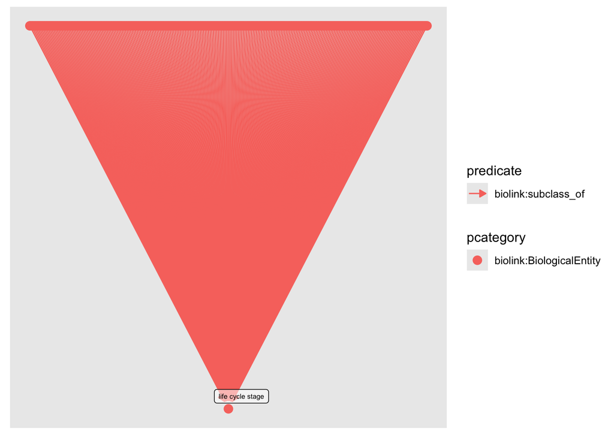

```r
quickplot(dev_stages)
```

Anyway, let’s find all of the descendants of DS, their phenotypes, and any connections to life stages of any of those:

```r
downs <- monarch_engine() |>
    fetch_nodes(query_ids = "MONDO:0008608") |> # Down
    expand(predicates = "biolink:subclass_of", direction = "in", transitive = TRUE) |>
    expand(result_categories = "biolink:PhenotypicFeature") |>
    expand(result_categories = "biolink:LifeStage")


downs
```

#### Nodes

Showing 100 of 112 nodes:

| id | pcategory | name | description | synonym (list) | category (list) | iri | xref (list) | provided_by (list) |
| --- | --- | --- | --- | --- | --- | --- | --- | --- |
| “MONDO:0008608” | “biolink:Disease” | “Down syndrome” | “Down syndrome is a chromosomal abnormality caused by the presence of a third (partial or total) copy of the chromosome 21 genetic material and that is characterized by variable intellectual disabilit… | c(“Down syndrome”, “Down syndrome chromosome region”, “Down syndrome critical region”, “Down syndrome, Isolated cases”, “Down’s syndrome”, “Down’s syndrome - trisomy 21”, “Downs syndrome”, “G trisomy”… | c(“biolink:BiologicalEntity”, “biolink:Disease”, “biolink:DiseaseOrPhenotypicFeature”, “biolink:Entity”, “biolink:NamedThing”, “biolink:ThingWithTaxon”) | “http://purl.obolibrary.org/obo/MONDO_0008608” | c(“DOID:14250”, “EFO:0001064”, “ICD9:758.0”, “MESH:D004314”, “MedDRA:10044688”, “NANDO:2200965”, “NCIT:C2993”, “NIFSTD:nlx_dys_20090502”, “OMIM:190685”, “Orphanet:870”, “SCTID:41040004”, “UMLS:C001308… | “phenio_nodes” |
| “MONDO:0700128” | “biolink:Disease” | “translocation Down syndrome” | “Down syndrome in which the extra (partial or total) copy of chromosome 21 genetic material is attached to another chromosome.” | “Robertsonian Translocation Trisomy 21” | c(“biolink:BiologicalEntity”, “biolink:Disease”, “biolink:DiseaseOrPhenotypicFeature”, “biolink:Entity”, “biolink:NamedThing”, “biolink:ThingWithTaxon”) | “http://purl.obolibrary.org/obo/MONDO_0700128” | NA | “phenio_nodes” |
| “MONDO:0700082” | “biolink:Disease” | “Robertsonian translocation Down syndrome” | “Chromosomal disorder in which (part or full) chromosome 21 is attached to another chromosome, resulting in the presence of a third copy of part of full chromosome 21 genetic material. A Robertsonian … | NA | c(“biolink:BiologicalEntity”, “biolink:Disease”, “biolink:DiseaseOrPhenotypicFeature”, “biolink:Entity”, “biolink:NamedThing”, “biolink:ThingWithTaxon”) | “http://purl.obolibrary.org/obo/MONDO_0700082” | “NCIT:C188150” | “phenio_nodes” |
| “MONDO:0700094” | “biolink:Disease” | “unbalanced Robertsonian translocation Down syndrome” | “Robertsonian translocation Down syndrome in which translocation displacement of the end regions of chromosomes occurred with loss of chromosomal material between the two nonhomologous chromosomes.” | NA | c(“biolink:BiologicalEntity”, “biolink:Disease”, “biolink:DiseaseOrPhenotypicFeature”, “biolink:Entity”, “biolink:NamedThing”, “biolink:ThingWithTaxon”) | “http://purl.obolibrary.org/obo/MONDO_0700094” | NA | “phenio_nodes” |
| “MONDO:0700093” | “biolink:Disease” | “balanced Robertsonian translocation Down syndrome” | “Robertsonian translocation Down syndrome in which translocation displacement of the end regions of chromosomes occurred without loss of chromosomal material between the two nonhomologous chromosomes.… | NA | c(“biolink:BiologicalEntity”, “biolink:Disease”, “biolink:DiseaseOrPhenotypicFeature”, “biolink:Entity”, “biolink:NamedThing”, “biolink:ThingWithTaxon”) | “http://purl.obolibrary.org/obo/MONDO_0700093” | NA | “phenio_nodes” |
| “MONDO:0700083” | “biolink:Disease” | “reciprocal translocation down syndrome” | “Chromosomal disorder in which (part or full) chromosome 21 has been exchange with another chromosome, resulting in the presence of a third copy of (part or full) chromosome 21 genetic material. A rec… | NA | c(“biolink:BiologicalEntity”, “biolink:Disease”, “biolink:DiseaseOrPhenotypicFeature”, “biolink:Entity”, “biolink:NamedThing”, “biolink:ThingWithTaxon”) | “http://purl.obolibrary.org/obo/MONDO_0700083” | NA | “phenio_nodes” |
| “MONDO:0700129” | “biolink:Disease” | “mosaic translocation Down syndrome” | “Translocation Down syndrome in which the extra (partial or total) copy of chromosome 21 attached to another chromosome is present in some of the cells of the organism.” | NA | c(“biolink:BiologicalEntity”, “biolink:Disease”, “biolink:DiseaseOrPhenotypicFeature”, “biolink:Entity”, “biolink:NamedThing”, “biolink:ThingWithTaxon”) | “http://purl.obolibrary.org/obo/MONDO_0700129” | NA | “phenio_nodes” |
| “MONDO:0700130” | “biolink:Disease” | “partial segmental duplication” | “A chromosomal disorder consisting of the partial duplication of chromosome 21.” | c(“partial trisomy 21”, “segmental duplication”) | c(“biolink:BiologicalEntity”, “biolink:Disease”, “biolink:DiseaseOrPhenotypicFeature”, “biolink:Entity”, “biolink:NamedThing”, “biolink:ThingWithTaxon”) | “http://purl.obolibrary.org/obo/MONDO_0700130” | NA | “phenio_nodes” |
| “MONDO:0700126” | “biolink:Disease” | “trisomy 21” | “A chromosomal disorder consisting of the presence of an extra chromosome 21.” | NA | c(“biolink:BiologicalEntity”, “biolink:Disease”, “biolink:DiseaseOrPhenotypicFeature”, “biolink:Entity”, “biolink:NamedThing”, “biolink:ThingWithTaxon”) | “http://purl.obolibrary.org/obo/MONDO_0700126” | NA | “phenio_nodes” |
| “MONDO:0700127” | “biolink:Disease” | “mosaic trisomy 21” | “Trisomy 21 characterized by the presence of an extra chromosome 21 in some of the cells of the organism.” | NA | c(“biolink:BiologicalEntity”, “biolink:Disease”, “biolink:DiseaseOrPhenotypicFeature”, “biolink:Entity”, “biolink:NamedThing”, “biolink:ThingWithTaxon”) | “http://purl.obolibrary.org/obo/MONDO_0700127” | NA | “phenio_nodes” |
| “MONDO:0700030” | “biolink:Disease” | “complete trisomy 21” | “Trisomy 21 characterized by the presence of an extra chromosome 21 in all the cells of the organism.” | “standard trisomy 21” | c(“biolink:BiologicalEntity”, “biolink:Disease”, “biolink:DiseaseOrPhenotypicFeature”, “biolink:Entity”, “biolink:NamedThing”, “biolink:ThingWithTaxon”) | “http://purl.obolibrary.org/obo/MONDO_0700030” | NA | “phenio_nodes” |
| “HP:0003196” | “biolink:PhenotypicFeature” | “Short nose” | “Distance from nasion to subnasale more than two standard deviations below the mean, or alternatively, an apparently decreased length from the nasal root to the nasal tip.” | c(“Decreased length of nose”, “Hypoplastic nose”, “Nasal hypoplasia”, “Short nose”, “Shortened nose”, “Small nose”) | c(“biolink:BiologicalEntity”, “biolink:DiseaseOrPhenotypicFeature”, “biolink:Entity”, “biolink:NamedThing”, “biolink:PhenotypicFeature”, “biolink:ThingWithTaxon”) | “http://purl.obolibrary.org/obo/HP_0003196” | c(“SNOMEDCT_US:249310005”, “UMLS:C0426414”, “UMLS:C1854114”) | “phenio_nodes” |
| “HP:0000235” | “biolink:PhenotypicFeature” | “Abnormality of the fontanelles or cranial sutures” | “Any abnormality of the fontanelles (the regions covered by a thick membrane that normally ossify in the first two years of life) or the cranial sutures (the fibrous joints in which the articulating b… | NA | c(“biolink:BiologicalEntity”, “biolink:DiseaseOrPhenotypicFeature”, “biolink:Entity”, “biolink:NamedThing”, “biolink:PhenotypicFeature”, “biolink:ThingWithTaxon”) | “http://purl.obolibrary.org/obo/HP_0000235” | “UMLS:C4025876” | “phenio_nodes” |
| “HP:0001629” | “biolink:PhenotypicFeature” | “Ventricular septal defect” | “A hole between the two bottom chambers (ventricles) of the heart. The defect is centered around the most superior aspect of the ventricular septum.” | c(“Hole in heart wall separating two lower heart chambers”, “VSD”, “Ventricular septal defects”, “Ventriculoseptal defect”) | c(“biolink:BiologicalEntity”, “biolink:DiseaseOrPhenotypicFeature”, “biolink:Entity”, “biolink:NamedThing”, “biolink:PhenotypicFeature”, “biolink:ThingWithTaxon”) | “http://purl.obolibrary.org/obo/HP_0001629” | c(“Fyler:1300”, “MSH:D006345”, “SNOMEDCT_US:253549006”, “SNOMEDCT_US:30288003”, “UMLS:C0018818”) | “phenio_nodes” |
| “HP:0001328” | “biolink:PhenotypicFeature” | “Specific learning disability” | “Impairment of certain skills such as reading or writing, coordination, self-control, or attention that interfere with the ability to learn. The impairment is not related to a global deficiency of int… | NA | c(“biolink:BiologicalEntity”, “biolink:DiseaseOrPhenotypicFeature”, “biolink:Entity”, “biolink:NamedThing”, “biolink:PhenotypicFeature”, “biolink:ThingWithTaxon”) | “http://purl.obolibrary.org/obo/HP_0001328” | “UMLS:C4025790” | “phenio_nodes” |
| “HP:0000545” | “biolink:PhenotypicFeature” | “Myopia” | “An abnormality of refraction characterized by the ability to see objects nearby clearly, while objects in the distance appear blurry.” | c(“Close sighted”, “Near sighted”, “Near sightedness”, “Nearsightedness”) | c(“biolink:BiologicalEntity”, “biolink:DiseaseOrPhenotypicFeature”, “biolink:Entity”, “biolink:NamedThing”, “biolink:PhenotypicFeature”, “biolink:ThingWithTaxon”) | “http://purl.obolibrary.org/obo/HP_0000545” | c(“MSH:D009216”, “SNOMEDCT_US:57190000”, “UMLS:C0027092”) | “phenio_nodes” |
| “HP:0000248” | “biolink:PhenotypicFeature” | “Brachycephaly” | “An abnormality of skull shape characterized by a decreased anterior-posterior diameter. That is, a cephalic index greater than 81%. Alternatively, an apparently shortened anteroposterior dimension (l… | c(“Broad cranium shape”, “Broad head shape”, “Broad skull shape”, “Short and broad skull”, “Wide cranium shape”, “Wide head shape”, “Wide skull shape”) | c(“biolink:BiologicalEntity”, “biolink:DiseaseOrPhenotypicFeature”, “biolink:Entity”, “biolink:NamedThing”, “biolink:PhenotypicFeature”, “biolink:ThingWithTaxon”) | “http://purl.obolibrary.org/obo/HP_0000248” | c(“MSH:D003398”, “SNOMEDCT_US:13649004”, “UMLS:C0221356”, “UMLS:C4072823”, “UMLS:C4072824”) | “phenio_nodes” |
| “HP:0002511” | “biolink:PhenotypicFeature” | “Alzheimer disease” | “A degenerative disease of the brain characterized by the insidious onset of dementia. Impairment of memory, judgment, attention span, and problem solving skills are followed by severe apraxia and a g… | c(“Alzheimer disease”, “Late-onset form of familial Alzheimer disease”) | c(“biolink:BiologicalEntity”, “biolink:DiseaseOrPhenotypicFeature”, “biolink:Entity”, “biolink:NamedThing”, “biolink:PhenotypicFeature”, “biolink:ThingWithTaxon”) | “http://purl.obolibrary.org/obo/HP_0002511” | c(“DOID:10652”, “MONDO:0004975”, “MSH:C536595”, “MSH:D000544”, “SNOMEDCT_US:230267005”, “SNOMEDCT_US:26929004”, “UMLS:C0002395”, “UMLS:C1863051”) | “phenio_nodes” |
| “HP:0003414” | “biolink:PhenotypicFeature” | “Atlantoaxial dislocation” | “Partial dislocation of the atlantoaxial joint.” | c(“Atlanto-axial subluxation”, “Atlantoaxial subluxation”) | c(“biolink:BiologicalEntity”, “biolink:DiseaseOrPhenotypicFeature”, “biolink:Entity”, “biolink:NamedThing”, “biolink:PhenotypicFeature”, “biolink:ThingWithTaxon”) | “http://purl.obolibrary.org/obo/HP_0003414” | c(“SNOMEDCT_US:263042007”, “SNOMEDCT_US:45179004”, “UMLS:C0263905”) | “phenio_nodes” |
| “HP:0001252” | “biolink:PhenotypicFeature” | “Hypotonia” | “Hypotonia is an abnormally low muscle tone (the amount of tension or resistance to movement in a muscle). Even when relaxed, muscles have a continuous and passive partial contraction which provides s… | c(“Central hypotonia”, “Low muscle tone”, “Low or weak muscle tone”, “Muscle hypotonia”, “Muscular hypotonia”, “Peripheral hypotonia”) | c(“biolink:BiologicalEntity”, “biolink:DiseaseOrPhenotypicFeature”, “biolink:Entity”, “biolink:NamedThing”, “biolink:PhenotypicFeature”, “biolink:ThingWithTaxon”) | “http://purl.obolibrary.org/obo/HP_0001252” | c(“MSH:D009123”, “SNOMEDCT_US:398151007”, “SNOMEDCT_US:398152000”, “UMLS:C0026827”) | “phenio_nodes” |
| “HP:0000954” | “biolink:PhenotypicFeature” | “Single transverse palmar crease” | “The distal and proximal transverse palmar creases are merged into a single transverse palmar crease.” | c(“Simian crease”, “Simian creases”, “Simian line”, “Single flexion crease”, “Single palmar crease”, “Single palmar creases”, “Single transverse palmar creases”, “Transverse palmar crease”) | c(“biolink:BiologicalEntity”, “biolink:DiseaseOrPhenotypicFeature”, “biolink:Entity”, “biolink:NamedThing”, “biolink:PhenotypicFeature”, “biolink:ThingWithTaxon”) | “http://purl.obolibrary.org/obo/HP_0000954” | c(“SNOMEDCT_US:248409006”, “UMLS:C0424731”) | “phenio_nodes” |
| “HP:0001156” | “biolink:PhenotypicFeature” | “Brachydactyly” | “Digits that appear disproportionately short compared to the hand/foot. The word brachydactyly is used here to describe a series distinct patterns of shortened digits (brachydactyly types A-E). This i… | c(“Brachydactyly syndrome”, “Short fingers or toes”) | c(“biolink:BiologicalEntity”, “biolink:DiseaseOrPhenotypicFeature”, “biolink:Entity”, “biolink:NamedThing”, “biolink:PhenotypicFeature”, “biolink:ThingWithTaxon”) | “http://purl.obolibrary.org/obo/HP_0001156” | c(“MSH:D059327”, “SNOMEDCT_US:43476002”, “UMLS:C0221357”) | “phenio_nodes” |
| “HP:0000286” | “biolink:PhenotypicFeature” | “Epicanthus” | “A fold of skin starting above the medial aspect of the upper eyelid and arching downward to cover, pass in front of and lateral to the medial canthus.” | c(“Epicanthal fold”, “Epicanthal folds”, “Epicanthic folds”, “Eye folds”, “Palpebronasal fold”, “Plica palpebronasalis”, “Prominent eye folds”) | c(“biolink:BiologicalEntity”, “biolink:DiseaseOrPhenotypicFeature”, “biolink:Entity”, “biolink:NamedThing”, “biolink:PhenotypicFeature”, “biolink:ThingWithTaxon”) | “http://purl.obolibrary.org/obo/HP_0000286” | “UMLS:C0678230” | “phenio_nodes” |
| “HP:0004279” | “biolink:PhenotypicFeature” | “Short palm” | “Short palm.” | c(“Hypoplastic hands”, “Short hands”, “Short palm”, “Short palms”) | c(“biolink:BiologicalEntity”, “biolink:DiseaseOrPhenotypicFeature”, “biolink:Entity”, “biolink:NamedThing”, “biolink:PhenotypicFeature”, “biolink:ThingWithTaxon”) | “http://purl.obolibrary.org/obo/HP_0004279” | “UMLS:C1843108” | “phenio_nodes” |
| “HP:0001852” | “biolink:PhenotypicFeature” | “Sandal gap” | “A widely spaced gap between the first toe (the great toe) and the second toe.” | c(“Gap between 1st and 2nd toes”, “Gap between first and second toe”, “Increased space between first and second toes”, “Sandal gap between first and second toes”, “Space between great toe and second t… | c(“biolink:BiologicalEntity”, “biolink:DiseaseOrPhenotypicFeature”, “biolink:Entity”, “biolink:NamedThing”, “biolink:PhenotypicFeature”, “biolink:ThingWithTaxon”) | “http://purl.obolibrary.org/obo/HP_0001852” | “UMLS:C1840069” | “phenio_nodes” |
| “HP:0000646” | “biolink:PhenotypicFeature” | “Amblyopia” | “Reduced visual acuity that is uncorrectable by lenses in the absence of detectable anatomic defects in the eye or visual pathways.” | c(“Lazy eye”, “Wandering eye”, “Wandering eyes”) | c(“biolink:BiologicalEntity”, “biolink:DiseaseOrPhenotypicFeature”, “biolink:Entity”, “biolink:NamedThing”, “biolink:PhenotypicFeature”, “biolink:ThingWithTaxon”) | “http://purl.obolibrary.org/obo/HP_0000646” | c(“MSH:D000550”, “SNOMEDCT_US:387742006”, “UMLS:C0002418”) | “phenio_nodes” |
| “HP:0010978” | “biolink:PhenotypicFeature” | “Abnormality of immune system physiology” | “A functional abnormality of the immune system.” | NA | c(“biolink:BiologicalEntity”, “biolink:DiseaseOrPhenotypicFeature”, “biolink:Entity”, “biolink:NamedThing”, “biolink:PhenotypicFeature”, “biolink:ThingWithTaxon”) | “http://purl.obolibrary.org/obo/HP_0010978” | “UMLS:C4023616” | “phenio_nodes” |
| “HP:0003182” | “biolink:PhenotypicFeature” | “Shallow acetabular fossae” | NA | c(“Shallow acetabula”, “Shallow acetabulae”, “Shallow acetabular fossa”, “Shallow acetabulum”) | c(“biolink:BiologicalEntity”, “biolink:DiseaseOrPhenotypicFeature”, “biolink:Entity”, “biolink:NamedThing”, “biolink:PhenotypicFeature”, “biolink:ThingWithTaxon”) | “http://purl.obolibrary.org/obo/HP_0003182” | c(“UMLS:C1854910”, “UMLS:C1860796”) | “phenio_nodes” |
| “HP:0025656” | “biolink:PhenotypicFeature” | “Prenatal double bubble sign” | “Sonographic detection of a double bubble sign in the upper abdomen is strongly indicative of duodenal obstruction. One bubble represents fetal stomach, and the other is attributed to a dilated proxim… | NA | c(“biolink:BiologicalEntity”, “biolink:DiseaseOrPhenotypicFeature”, “biolink:Entity”, “biolink:NamedThing”, “biolink:PhenotypicFeature”, “biolink:ThingWithTaxon”) | “http://purl.obolibrary.org/obo/HP_0025656” | NA | “phenio_nodes” |
| “HP:0001513” | “biolink:PhenotypicFeature” | “Obesity” | “Accumulation of substantial excess body fat.” | c(“Having too much body fat”, “Obesity”) | c(“biolink:BiologicalEntity”, “biolink:DiseaseOrPhenotypicFeature”, “biolink:Entity”, “biolink:NamedThing”, “biolink:PhenotypicFeature”, “biolink:ThingWithTaxon”) | “http://purl.obolibrary.org/obo/HP_0001513” | c(“MSH:D009765”, “SNOMEDCT_US:414915002”, “SNOMEDCT_US:414916001”, “UMLS:C0028754”) | “phenio_nodes” |

[output cut: 70 more lines]

#### Edges

Showing 100 of 111 edges:

| from | to | subject | predicate | object | agent_type | knowledge_level | knowledge_source | aggregator_knowledge_source (list) | primary_knowledge_source | provided_by (list) | id | category (list) | frequency_qualifier | original_subject | has_evidence (list) | has_quotient | has_total | has_count | has_percentage | publications (list) |
| --- | --- | --- | --- | --- | --- | --- | --- | --- | --- | --- | --- | --- | --- | --- | --- | --- | --- | --- | --- | --- |
| 2 | 1 | “MONDO:0700128” | “biolink:subclass_of” | “MONDO:0008608” | “not_provided” | “not_provided” | “monarch-kg_edges.jsonl” | c(“infores:monarchinitiative”, “infores:phenio”) | “infores:mondo” | “phenio_edges” | “urn:uuid:e7039e57-91c9-46da-aed3-9c9723e08242” | c(“biolink:Association”, “biolink:Entity”) | NA | NA | NULL | NA | NA | NA | NA | NULL |
| 3 | 2 | “MONDO:0700082” | “biolink:subclass_of” | “MONDO:0700128” | “not_provided” | “not_provided” | “monarch-kg_edges.jsonl” | c(“infores:monarchinitiative”, “infores:phenio”) | “infores:mondo” | “phenio_edges” | “urn:uuid:46df2cb1-0f33-4963-9ca9-ef6da944d0e3” | c(“biolink:Association”, “biolink:Entity”) | NA | NA | NULL | NA | NA | NA | NA | NULL |
| 4 | 3 | “MONDO:0700094” | “biolink:subclass_of” | “MONDO:0700082” | “not_provided” | “not_provided” | “monarch-kg_edges.jsonl” | c(“infores:monarchinitiative”, “infores:phenio”) | “infores:mondo” | “phenio_edges” | “urn:uuid:984d0e40-1f8a-4a32-9fbe-bb1167574252” | c(“biolink:Association”, “biolink:Entity”) | NA | NA | NULL | NA | NA | NA | NA | NULL |
| 5 | 3 | “MONDO:0700093” | “biolink:subclass_of” | “MONDO:0700082” | “not_provided” | “not_provided” | “monarch-kg_edges.jsonl” | c(“infores:monarchinitiative”, “infores:phenio”) | “infores:mondo” | “phenio_edges” | “urn:uuid:c40a22c9-edaf-437e-9601-1f0dacb14b35” | c(“biolink:Association”, “biolink:Entity”) | NA | NA | NULL | NA | NA | NA | NA | NULL |
| 6 | 2 | “MONDO:0700083” | “biolink:subclass_of” | “MONDO:0700128” | “not_provided” | “not_provided” | “monarch-kg_edges.jsonl” | c(“infores:monarchinitiative”, “infores:phenio”) | “infores:mondo” | “phenio_edges” | “urn:uuid:dea0dde9-d130-4154-9f30-71e8647148f0” | c(“biolink:Association”, “biolink:Entity”) | NA | NA | NULL | NA | NA | NA | NA | NULL |
| 7 | 2 | “MONDO:0700129” | “biolink:subclass_of” | “MONDO:0700128” | “not_provided” | “not_provided” | “monarch-kg_edges.jsonl” | c(“infores:monarchinitiative”, “infores:phenio”) | “infores:mondo” | “phenio_edges” | “urn:uuid:eb07f391-0a61-496d-8ae5-950b125a0d30” | c(“biolink:Association”, “biolink:Entity”) | NA | NA | NULL | NA | NA | NA | NA | NULL |
| 8 | 1 | “MONDO:0700130” | “biolink:subclass_of” | “MONDO:0008608” | “not_provided” | “not_provided” | “monarch-kg_edges.jsonl” | c(“infores:monarchinitiative”, “infores:phenio”) | “infores:mondo” | “phenio_edges” | “urn:uuid:5940b73b-b22c-4fcc-b1ba-18066f3f4141” | c(“biolink:Association”, “biolink:Entity”) | NA | NA | NULL | NA | NA | NA | NA | NULL |
| 9 | 1 | “MONDO:0700126” | “biolink:subclass_of” | “MONDO:0008608” | “not_provided” | “not_provided” | “monarch-kg_edges.jsonl” | c(“infores:monarchinitiative”, “infores:phenio”) | “infores:mondo” | “phenio_edges” | “urn:uuid:8b719c4a-ac84-4c2f-be05-c18acbdc4578” | c(“biolink:Association”, “biolink:Entity”) | NA | NA | NULL | NA | NA | NA | NA | NULL |
| 10 | 9 | “MONDO:0700127” | “biolink:subclass_of” | “MONDO:0700126” | “not_provided” | “not_provided” | “monarch-kg_edges.jsonl” | c(“infores:monarchinitiative”, “infores:phenio”) | “infores:mondo” | “phenio_edges” | “urn:uuid:77aaa10c-0a84-45ef-834b-15b9421af6a4” | c(“biolink:Association”, “biolink:Entity”) | NA | NA | NULL | NA | NA | NA | NA | NULL |
| 11 | 9 | “MONDO:0700030” | “biolink:subclass_of” | “MONDO:0700126” | “not_provided” | “not_provided” | “monarch-kg_edges.jsonl” | c(“infores:monarchinitiative”, “infores:phenio”) | “infores:mondo” | “phenio_edges” | “urn:uuid:249ade91-8706-4667-8e12-8f8f0d5054a4” | c(“biolink:Association”, “biolink:Entity”) | NA | NA | NULL | NA | NA | NA | NA | NULL |
| 1 | 12 | “MONDO:0008608” | “biolink:has_phenotype” | “HP:0003196” | “manual_agent” | “knowledge_assertion” | “monarch-kg_edges.jsonl” | “infores:monarchinitiative” | “infores:hpo-annotations” | “hpoa_disease_to_phenotype_edges” | “uuid:0f44512d-26da-11ef-bf5b-4d3880f6f3e2” | c(“biolink:Association”, “biolink:DiseaseToEntityAssociationMixin”, “biolink:DiseaseToPhenotypicFeatureAssociation”, “biolink:Entity”, “biolink:EntityToFeatureOrDiseaseQualifiersMixin”, “biolink:Entit… | “HP:0040282” | “Orphanet:870” | “ECO:0000304” | NA | NA | NA | NA | NA |
| 1 | 13 | “MONDO:0008608” | “biolink:has_phenotype” | “HP:0000235” | “manual_agent” | “knowledge_assertion” | “monarch-kg_edges.jsonl” | “infores:monarchinitiative” | “infores:hpo-annotations” | “hpoa_disease_to_phenotype_edges” | “uuid:0f44511e-26da-11ef-bf5b-4d3880f6f3e2” | c(“biolink:Association”, “biolink:DiseaseToEntityAssociationMixin”, “biolink:DiseaseToPhenotypicFeatureAssociation”, “biolink:Entity”, “biolink:EntityToFeatureOrDiseaseQualifiersMixin”, “biolink:Entit… | “HP:0040282” | “Orphanet:870” | “ECO:0000304” | NA | NA | NA | NA | NA |
| 1 | 14 | “MONDO:0008608” | “biolink:has_phenotype” | “HP:0001629” | “manual_agent” | “knowledge_assertion” | “monarch-kg_edges.jsonl” | “infores:monarchinitiative” | “infores:hpo-annotations” | “hpoa_disease_to_phenotype_edges” | “uuid:0f445124-26da-11ef-bf5b-4d3880f6f3e2” | c(“biolink:Association”, “biolink:DiseaseToEntityAssociationMixin”, “biolink:DiseaseToPhenotypicFeatureAssociation”, “biolink:Entity”, “biolink:EntityToFeatureOrDiseaseQualifiersMixin”, “biolink:Entit… | “HP:0040282” | “Orphanet:870” | “ECO:0000304” | “0.46551724137931033” | “58” | “27” | “46.55172413793103” | “PMID:15036797” |
| 1 | 15 | “MONDO:0008608” | “biolink:has_phenotype” | “HP:0001328” | “manual_agent” | “knowledge_assertion” | “monarch-kg_edges.jsonl” | “infores:monarchinitiative” | “infores:hpo-annotations” | “hpoa_disease_to_phenotype_edges” | “uuid:0f445111-26da-11ef-bf5b-4d3880f6f3e2” | c(“biolink:Association”, “biolink:DiseaseToEntityAssociationMixin”, “biolink:DiseaseToPhenotypicFeatureAssociation”, “biolink:Entity”, “biolink:EntityToFeatureOrDiseaseQualifiersMixin”, “biolink:Entit… | “HP:0040281” | “Orphanet:870” | “ECO:0000304” | NA | NA | NA | NA | NA |
| 1 | 16 | “MONDO:0008608” | “biolink:has_phenotype” | “HP:0000545” | “manual_agent” | “knowledge_assertion” | “monarch-kg_edges.jsonl” | “infores:monarchinitiative” | “infores:hpo-annotations” | “hpoa_disease_to_phenotype_edges” | “uuid:0f44513b-26da-11ef-bf5b-4d3880f6f3e2” | c(“biolink:Association”, “biolink:DiseaseToEntityAssociationMixin”, “biolink:DiseaseToPhenotypicFeatureAssociation”, “biolink:Entity”, “biolink:EntityToFeatureOrDiseaseQualifiersMixin”, “biolink:Entit… | “HP:0040283” | “Orphanet:870” | “ECO:0000304” | NA | NA | NA | NA | NA |
| 1 | 17 | “MONDO:0008608” | “biolink:has_phenotype” | “HP:0000248” | “manual_agent” | “knowledge_assertion” | “monarch-kg_edges.jsonl” | “infores:monarchinitiative” | “infores:hpo-annotations” | “hpoa_disease_to_phenotype_edges” | “uuid:0f445109-26da-11ef-bf5b-4d3880f6f3e2” | c(“biolink:Association”, “biolink:DiseaseToEntityAssociationMixin”, “biolink:DiseaseToPhenotypicFeatureAssociation”, “biolink:Entity”, “biolink:EntityToFeatureOrDiseaseQualifiersMixin”, “biolink:Entit… | “HP:0040281” | “Orphanet:870” | “ECO:0000304” | NA | NA | NA | NA | NA |
| 1 | 18 | “MONDO:0008608” | “biolink:has_phenotype” | “HP:0002511” | “manual_agent” | “knowledge_assertion” | “monarch-kg_edges.jsonl” | “infores:monarchinitiative” | “infores:hpo-annotations” | “hpoa_disease_to_phenotype_edges” | “uuid:0f44512b-26da-11ef-bf5b-4d3880f6f3e2” | c(“biolink:Association”, “biolink:DiseaseToEntityAssociationMixin”, “biolink:DiseaseToPhenotypicFeatureAssociation”, “biolink:Entity”, “biolink:EntityToFeatureOrDiseaseQualifiersMixin”, “biolink:Entit… | “HP:0040282” | “Orphanet:870” | “ECO:0000304” | NA | NA | NA | NA | NA |
| 1 | 19 | “MONDO:0008608” | “biolink:has_phenotype” | “HP:0003414” | “manual_agent” | “knowledge_assertion” | “monarch-kg_edges.jsonl” | “infores:monarchinitiative” | “infores:hpo-annotations” | “hpoa_disease_to_phenotype_edges” | “uuid:0f445149-26da-11ef-bf5b-4d3880f6f3e2” | c(“biolink:Association”, “biolink:DiseaseToEntityAssociationMixin”, “biolink:DiseaseToPhenotypicFeatureAssociation”, “biolink:Entity”, “biolink:EntityToFeatureOrDiseaseQualifiersMixin”, “biolink:Entit… | “HP:0040283” | “Orphanet:870” | “ECO:0000304” | NA | NA | NA | NA | NA |
| 1 | 20 | “MONDO:0008608” | “biolink:has_phenotype” | “HP:0001252” | “manual_agent” | “knowledge_assertion” | “monarch-kg_edges.jsonl” | “infores:monarchinitiative” | “infores:hpo-annotations” | “hpoa_disease_to_phenotype_edges” | “uuid:0f445110-26da-11ef-bf5b-4d3880f6f3e2” | c(“biolink:Association”, “biolink:DiseaseToEntityAssociationMixin”, “biolink:DiseaseToPhenotypicFeatureAssociation”, “biolink:Entity”, “biolink:EntityToFeatureOrDiseaseQualifiersMixin”, “biolink:Entit… | “HP:0040281” | “Orphanet:870” | “ECO:0000304” | “0.7633587786259542” | “524” | “400” | “76.33587786259542” | NA |
| 1 | 21 | “MONDO:0008608” | “biolink:has_phenotype” | “HP:0000954” | “manual_agent” | “knowledge_assertion” | “monarch-kg_edges.jsonl” | “infores:monarchinitiative” | “infores:hpo-annotations” | “hpoa_disease_to_phenotype_edges” | “uuid:0cc8d54a-26da-11ef-bf5b-4d3880f6f3e2” | c(“biolink:Association”, “biolink:DiseaseToEntityAssociationMixin”, “biolink:DiseaseToPhenotypicFeatureAssociation”, “biolink:Entity”, “biolink:EntityToFeatureOrDiseaseQualifiersMixin”, “biolink:Entit… | NA | “OMIM:190685” | “ECO:0000269” | “0.3445692883895131” | “534” | “184” | “34.45692883895131” | “PMID:15036797” |
| 1 | 22 | “MONDO:0008608” | “biolink:has_phenotype” | “HP:0001156” | “manual_agent” | “knowledge_assertion” | “monarch-kg_edges.jsonl” | “infores:monarchinitiative” | “infores:hpo-annotations” | “hpoa_disease_to_phenotype_edges” | “uuid:0f44510e-26da-11ef-bf5b-4d3880f6f3e2” | c(“biolink:Association”, “biolink:DiseaseToEntityAssociationMixin”, “biolink:DiseaseToPhenotypicFeatureAssociation”, “biolink:Entity”, “biolink:EntityToFeatureOrDiseaseQualifiersMixin”, “biolink:Entit… | “HP:0040281” | “Orphanet:870” | “ECO:0000304” | “0.11068702290076336” | “524” | “58” | “11.068702290076336” | “PMID:15036797” |
| 1 | 23 | “MONDO:0008608” | “biolink:has_phenotype” | “HP:0000286” | “manual_agent” | “knowledge_assertion” | “monarch-kg_edges.jsonl” | “infores:monarchinitiative” | “infores:hpo-annotations” | “hpoa_disease_to_phenotype_edges” | “uuid:0f44510a-26da-11ef-bf5b-4d3880f6f3e2” | c(“biolink:Association”, “biolink:DiseaseToEntityAssociationMixin”, “biolink:DiseaseToPhenotypicFeatureAssociation”, “biolink:Entity”, “biolink:EntityToFeatureOrDiseaseQualifiersMixin”, “biolink:Entit… | “HP:0040281” | “Orphanet:870” | “ECO:0000304” | “0.5687022900763359” | “524” | “298” | “56.87022900763359” | NA |
| 1 | 24 | “MONDO:0008608” | “biolink:has_phenotype” | “HP:0004279” | “manual_agent” | “knowledge_assertion” | “monarch-kg_edges.jsonl” | “infores:monarchinitiative” | “infores:hpo-annotations” | “hpoa_disease_to_phenotype_edges” | “uuid:0cc8d568-26da-11ef-bf5b-4d3880f6f3e2” | c(“biolink:Association”, “biolink:DiseaseToEntityAssociationMixin”, “biolink:DiseaseToPhenotypicFeatureAssociation”, “biolink:Entity”, “biolink:EntityToFeatureOrDiseaseQualifiersMixin”, “biolink:Entit… | NA | “OMIM:190685” | “ECO:0000304” | NA | NA | NA | NA | NA |
| 1 | 25 | “MONDO:0008608” | “biolink:has_phenotype” | “HP:0001852” | “manual_agent” | “knowledge_assertion” | “monarch-kg_edges.jsonl” | “infores:monarchinitiative” | “infores:hpo-annotations” | “hpoa_disease_to_phenotype_edges” | “uuid:0f445125-26da-11ef-bf5b-4d3880f6f3e2” | c(“biolink:Association”, “biolink:DiseaseToEntityAssociationMixin”, “biolink:DiseaseToPhenotypicFeatureAssociation”, “biolink:Entity”, “biolink:EntityToFeatureOrDiseaseQualifiersMixin”, “biolink:Entit… | “HP:0040282” | “Orphanet:870” | “ECO:0000304” | “0.4618320610687023” | “524” | “242” | “46.18320610687023” | “PMID:15036797” |
| 1 | 26 | “MONDO:0008608” | “biolink:has_phenotype” | “HP:0000646” | “manual_agent” | “knowledge_assertion” | “monarch-kg_edges.jsonl” | “infores:monarchinitiative” | “infores:hpo-annotations” | “hpoa_disease_to_phenotype_edges” | “uuid:0f44513d-26da-11ef-bf5b-4d3880f6f3e2” | c(“biolink:Association”, “biolink:DiseaseToEntityAssociationMixin”, “biolink:DiseaseToPhenotypicFeatureAssociation”, “biolink:Entity”, “biolink:EntityToFeatureOrDiseaseQualifiersMixin”, “biolink:Entit… | “HP:0040283” | “Orphanet:870” | “ECO:0000304” | NA | NA | NA | NA | NA |
| 1 | 27 | “MONDO:0008608” | “biolink:has_phenotype” | “HP:0010978” | “manual_agent” | “knowledge_assertion” | “monarch-kg_edges.jsonl” | “infores:monarchinitiative” | “infores:hpo-annotations” | “hpoa_disease_to_phenotype_edges” | “uuid:0f445134-26da-11ef-bf5b-4d3880f6f3e2” | c(“biolink:Association”, “biolink:DiseaseToEntityAssociationMixin”, “biolink:DiseaseToPhenotypicFeatureAssociation”, “biolink:Entity”, “biolink:EntityToFeatureOrDiseaseQualifiersMixin”, “biolink:Entit… | “HP:0040282” | “Orphanet:870” | “ECO:0000304” | NA | NA | NA | NA | NA |
| 1 | 28 | “MONDO:0008608” | “biolink:has_phenotype” | “HP:0003182” | “manual_agent” | “knowledge_assertion” | “monarch-kg_edges.jsonl” | “infores:monarchinitiative” | “infores:hpo-annotations” | “hpoa_disease_to_phenotype_edges” | “uuid:0cc8d56d-26da-11ef-bf5b-4d3880f6f3e2” | c(“biolink:Association”, “biolink:DiseaseToEntityAssociationMixin”, “biolink:DiseaseToPhenotypicFeatureAssociation”, “biolink:Entity”, “biolink:EntityToFeatureOrDiseaseQualifiersMixin”, “biolink:Entit… | NA | “OMIM:190685” | “ECO:0000501” | NA | NA | NA | NA | NA |
| 1 | 29 | “MONDO:0008608” | “biolink:has_phenotype” | “HP:0025656” | “manual_agent” | “knowledge_assertion” | “monarch-kg_edges.jsonl” | “infores:monarchinitiative” | “infores:hpo-annotations” | “hpoa_disease_to_phenotype_edges” | “uuid:0cc8d54b-26da-11ef-bf5b-4d3880f6f3e2” | c(“biolink:Association”, “biolink:DiseaseToEntityAssociationMixin”, “biolink:DiseaseToPhenotypicFeatureAssociation”, “biolink:Entity”, “biolink:EntityToFeatureOrDiseaseQualifiersMixin”, “biolink:Entit… | NA | “OMIM:190685” | “ECO:0000269” | NA | NA | NA | NA | “PMID:31167209” |
| 1 | 30 | “MONDO:0008608” | “biolink:has_phenotype” | “HP:0001513” | “manual_agent” | “knowledge_assertion” | “monarch-kg_edges.jsonl” | “infores:monarchinitiative” | “infores:hpo-annotations” | “hpoa_disease_to_phenotype_edges” | “uuid:0f445122-26da-11ef-bf5b-4d3880f6f3e2” | c(“biolink:Association”, “biolink:DiseaseToEntityAssociationMixin”, “biolink:DiseaseToPhenotypicFeatureAssociation”, “biolink:Entity”, “biolink:EntityToFeatureOrDiseaseQualifiersMixin”, “biolink:Entit… | “HP:0040282” | “Orphanet:870” | “ECO:0000304” | NA | NA | NA | NA | NA |
| 1 | 31 | “MONDO:0008608” | “biolink:has_phenotype” | “HP:0001873” | “manual_agent” | “knowledge_assertion” | “monarch-kg_edges.jsonl” | “infores:monarchinitiative” | “infores:hpo-annotations” | “hpoa_disease_to_phenotype_edges” | “uuid:0f445127-26da-11ef-bf5b-4d3880f6f3e2” | c(“biolink:Association”, “biolink:DiseaseToEntityAssociationMixin”, “biolink:DiseaseToPhenotypicFeatureAssociation”, “biolink:Entity”, “biolink:EntityToFeatureOrDiseaseQualifiersMixin”, “biolink:Entit… | “HP:0040282” | “Orphanet:870” | “ECO:0000304” | NA | NA | NA | NA | NA |

[output cut: 70 more lines]

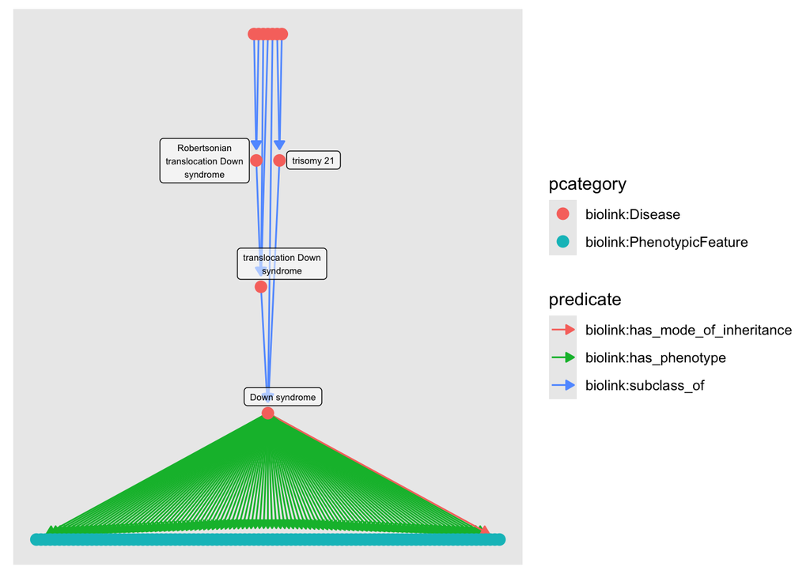

```r
quickplot(downs)
```

Nada. Let’s find out what these life stages *are* connected to.

```r
stages_expanded <- dev_stages |>
    expand()

stages_expanded
```

#### Nodes

Showing 100 of 241 nodes:

| id | pcategory | name | description | synonym (list) | category (list) | iri | xref (list) | provided_by (list) |
| --- | --- | --- | --- | --- | --- | --- | --- | --- |
| “HSAPDV:0000000” | “biolink:BiologicalEntity” | “life cycle stage” | “A spatiotemporal region encompassing some part of the life cycle of an organism.” | c(“developmental stage”, “stage”) | c(“biolink:BiologicalEntity”, “biolink:Entity”, “biolink:LifeStage”, “biolink:NamedThing”, “biolink:OrganismalEntity”, “biolink:SubjectOfInvestigation”, “biolink:ThingWithTaxon”) | “http://purl.obolibrary.org/obo/HsapDv_0000000” | “UBERON:0000105” | “phenio_nodes” |
| “HSAPDV:0000057” | “biolink:BiologicalEntity” | “20th week post-fertilization stage” | “Fetal stage when the fetus is over 19 and under 20 weeks of development.” | NA | c(“biolink:BiologicalEntity”, “biolink:Entity”, “biolink:LifeStage”, “biolink:NamedThing”, “biolink:OrganismalEntity”, “biolink:SubjectOfInvestigation”, “biolink:ThingWithTaxon”) | “http://purl.obolibrary.org/obo/HsapDv_0000057” | “EV:0300021” | “phenio_nodes” |
| “HSAPDV:0000186” | “biolink:BiologicalEntity” | “13-month-old stage” | “Infant stage that refers to an infant who is over 13 and under 14 months old.” | NA | c(“biolink:BiologicalEntity”, “biolink:Entity”, “biolink:LifeStage”, “biolink:NamedThing”, “biolink:OrganismalEntity”, “biolink:SubjectOfInvestigation”, “biolink:ThingWithTaxon”) | “http://purl.obolibrary.org/obo/HsapDv_0000186” | NA | “phenio_nodes” |
| “HSAPDV:0000030” | “biolink:BiologicalEntity” | “Carnegie stage 23” | “Organogenesis stage during which the head, the body, and the limbs are rounded structures.” | “CS23” | c(“biolink:BiologicalEntity”, “biolink:Entity”, “biolink:LifeStage”, “biolink:NamedThing”, “biolink:OrganismalEntity”, “biolink:SubjectOfInvestigation”, “biolink:ThingWithTaxon”) | “http://purl.obolibrary.org/obo/HsapDv_0000030” | c(“FMA:295926”, “FMA:63631”, “XUO:0000152”) | “phenio_nodes” |
| “HSAPDV:0000107” | “biolink:BiologicalEntity” | “13-year-old stage” | “Adolescent stage that refers to an adolescent who is over 13 and under 14 years old.” | NA | c(“biolink:BiologicalEntity”, “biolink:Entity”, “biolink:LifeStage”, “biolink:NamedThing”, “biolink:OrganismalEntity”, “biolink:SubjectOfInvestigation”, “biolink:ThingWithTaxon”) | “http://purl.obolibrary.org/obo/HsapDv_0000107” | “EV:0300065” | “phenio_nodes” |
| “HSAPDV:0000246” | “biolink:BiologicalEntity” | “1-year-old stage” | “Child stage that refers to a child who is over 12 and under 24 months old.” | “12-23 months” | c(“biolink:BiologicalEntity”, “biolink:Entity”, “biolink:LifeStage”, “biolink:NamedThing”, “biolink:OrganismalEntity”, “biolink:SubjectOfInvestigation”, “biolink:ThingWithTaxon”) | “http://purl.obolibrary.org/obo/HsapDv_0000246” | NA | “phenio_nodes” |
| “HSAPDV:0000213” | “biolink:BiologicalEntity” | “87-year-old stage” | “Aged stage that refers to an adult who is over 87 and under 88 years old.” | NA | c(“biolink:BiologicalEntity”, “biolink:Entity”, “biolink:LifeStage”, “biolink:NamedThing”, “biolink:OrganismalEntity”, “biolink:SubjectOfInvestigation”, “biolink:ThingWithTaxon”) | “http://purl.obolibrary.org/obo/HsapDv_0000213” | NA | “phenio_nodes” |
| “HSAPDV:0000217” | “biolink:BiologicalEntity” | “91-year-old stage” | “Aged stage that refers to an adult who is over 91 and under 92 years old.” | NA | c(“biolink:BiologicalEntity”, “biolink:Entity”, “biolink:LifeStage”, “biolink:NamedThing”, “biolink:OrganismalEntity”, “biolink:SubjectOfInvestigation”, “biolink:ThingWithTaxon”) | “http://purl.obolibrary.org/obo/HsapDv_0000217” | NA | “phenio_nodes” |
| “HSAPDV:0000034” | “biolink:BiologicalEntity” | “Carnegie stage 06a” | “Carnegie developmental stage 6 during which chorionic villi appear.” | “CS06a” | c(“biolink:BiologicalEntity”, “biolink:Entity”, “biolink:LifeStage”, “biolink:NamedThing”, “biolink:OrganismalEntity”, “biolink:SubjectOfInvestigation”, “biolink:ThingWithTaxon”) | “http://purl.obolibrary.org/obo/HsapDv_0000034” | c(“EHDAA2:CS06a”, “XUO:0000190”) | “phenio_nodes” |
| “HSAPDV:0000197” | “biolink:BiologicalEntity” | “third LMP month stage” | “Fetal stage that refers to the third month of gestation starting from the last menstrual period (LMP).” | NA | c(“biolink:BiologicalEntity”, “biolink:Entity”, “biolink:LifeStage”, “biolink:NamedThing”, “biolink:OrganismalEntity”, “biolink:SubjectOfInvestigation”, “biolink:ThingWithTaxon”) | “http://purl.obolibrary.org/obo/HsapDv_0000197” | NA | “phenio_nodes” |
| “HSAPDV:0000129” | “biolink:BiologicalEntity” | “35-year-old stage” | “Adult stage that refers to an adult who is over 35 and under 36 years old.” | NA | c(“biolink:BiologicalEntity”, “biolink:Entity”, “biolink:LifeStage”, “biolink:NamedThing”, “biolink:OrganismalEntity”, “biolink:SubjectOfInvestigation”, “biolink:ThingWithTaxon”) | “http://purl.obolibrary.org/obo/HsapDv_0000129” | “EV:0300088” | “phenio_nodes” |
| “HSAPDV:0000003” | “biolink:BiologicalEntity” | “Carnegie stage 01” | “Embryonic stage defined by a fertilized oocyte and presence of pronuclei.” | “CS01” | c(“biolink:BiologicalEntity”, “biolink:Entity”, “biolink:LifeStage”, “biolink:NamedThing”, “biolink:OrganismalEntity”, “biolink:SubjectOfInvestigation”, “biolink:ThingWithTaxon”) | “http://purl.obolibrary.org/obo/HsapDv_0000003” | c(“EHDAA2:CS01”, “FMA:295882”, “UBERON:0000106”, “XUO:0000130”) | “phenio_nodes” |
| “HSAPDV:0000144” | “biolink:BiologicalEntity” | “50-year-old stage” | “Middle aged stage that refers to an adult who is over 50 and under 51 years old.” | NA | c(“biolink:BiologicalEntity”, “biolink:Entity”, “biolink:LifeStage”, “biolink:NamedThing”, “biolink:OrganismalEntity”, “biolink:SubjectOfInvestigation”, “biolink:ThingWithTaxon”) | “http://purl.obolibrary.org/obo/HsapDv_0000144” | “EV:0300103” | “phenio_nodes” |
| “HSAPDV:0000253” | “biolink:BiologicalEntity” | “112-year-old stage” | “Aged stage that refers to an adult who is over 112 and under 113 years old.” | NA | c(“biolink:BiologicalEntity”, “biolink:Entity”, “biolink:LifeStage”, “biolink:NamedThing”, “biolink:OrganismalEntity”, “biolink:SubjectOfInvestigation”, “biolink:ThingWithTaxon”) | “http://purl.obolibrary.org/obo/HsapDv_0000253” | NA | “phenio_nodes” |
| “HSAPDV:0000208” | “biolink:BiologicalEntity” | “82-year-old stage” | “Aged stage that refers to an adult who is over 82 and under 83 years old.” | NA | c(“biolink:BiologicalEntity”, “biolink:Entity”, “biolink:LifeStage”, “biolink:NamedThing”, “biolink:OrganismalEntity”, “biolink:SubjectOfInvestigation”, “biolink:ThingWithTaxon”) | “http://purl.obolibrary.org/obo/HsapDv_0000208” | NA | “phenio_nodes” |
| “HSAPDV:0000247” | “biolink:BiologicalEntity” | “centenarian stage” | “Aged stage that refers to an adult who is over 100 years old.” | NA | c(“biolink:BiologicalEntity”, “biolink:Entity”, “biolink:LifeStage”, “biolink:NamedThing”, “biolink:OrganismalEntity”, “biolink:SubjectOfInvestigation”, “biolink:ThingWithTaxon”) | “http://purl.obolibrary.org/obo/HsapDv_0000247” | NA | “phenio_nodes” |
| “HSAPDV:0000033” | “biolink:BiologicalEntity” | “Carnegie stage 05c” | “Carnegie developmental stage 5 defined by a lacunar vascular circle.” | “CS05c” | c(“biolink:BiologicalEntity”, “biolink:Entity”, “biolink:LifeStage”, “biolink:NamedThing”, “biolink:OrganismalEntity”, “biolink:SubjectOfInvestigation”, “biolink:ThingWithTaxon”) | “http://purl.obolibrary.org/obo/HsapDv_0000033” | c(“EHDAA2:CS05c”, “FMA:296711”, “XUO:0000189”) | “phenio_nodes” |
| “HSAPDV:0000267” | “biolink:BiologicalEntity” | “middle aged stage” | “Late adulthood that refers to an adult who is over 40 and under 60 years old.” | NA | c(“biolink:BiologicalEntity”, “biolink:Entity”, “biolink:LifeStage”, “biolink:NamedThing”, “biolink:OrganismalEntity”, “biolink:SubjectOfInvestigation”, “biolink:ThingWithTaxon”) | “http://purl.obolibrary.org/obo/HsapDv_0000267” | “HP:0003596” | “phenio_nodes” |
| “HSAPDV:0000070” | “biolink:BiologicalEntity” | “33rd week post-fertilization stage” | “Fetal stage when the fetus is over 32 and under 33 weeks of development.” | NA | c(“biolink:BiologicalEntity”, “biolink:Entity”, “biolink:LifeStage”, “biolink:NamedThing”, “biolink:OrganismalEntity”, “biolink:SubjectOfInvestigation”, “biolink:ThingWithTaxon”) | “http://purl.obolibrary.org/obo/HsapDv_0000070” | NA | “phenio_nodes” |
| “HSAPDV:0000270” | “biolink:BiologicalEntity” | “2-4 year-old child stage” | “Child stage that refers to a child who is over 2 and under 5 years old.” | NA | c(“biolink:BiologicalEntity”, “biolink:Entity”, “biolink:LifeStage”, “biolink:NamedThing”, “biolink:OrganismalEntity”, “biolink:SubjectOfInvestigation”, “biolink:ThingWithTaxon”) | “http://purl.obolibrary.org/obo/HsapDv_0000270” | NA | “phenio_nodes” |
| “HSAPDV:0000261” | “biolink:BiologicalEntity” | “infant stage” | “Immature stage that refers to an infant who is over 28 days and is under 12 months old.” | c(“infantile stage”, “under-1-year-old stage”) | c(“biolink:BiologicalEntity”, “biolink:Entity”, “biolink:LifeStage”, “biolink:NamedThing”, “biolink:OrganismalEntity”, “biolink:SubjectOfInvestigation”, “biolink:ThingWithTaxon”) | “http://purl.obolibrary.org/obo/HsapDv_0000261” | c(“HP:0003593”, “UBERON:0034920”) | “phenio_nodes” |
| “HSAPDV:0000059” | “biolink:BiologicalEntity” | “22nd week post-fertilization stage” | “Fetal stage when the fetus is over 21 and under 22 weeks of development.” | NA | c(“biolink:BiologicalEntity”, “biolink:Entity”, “biolink:LifeStage”, “biolink:NamedThing”, “biolink:OrganismalEntity”, “biolink:SubjectOfInvestigation”, “biolink:ThingWithTaxon”) | “http://purl.obolibrary.org/obo/HsapDv_0000059” | “EV:0300022” | “phenio_nodes” |
| “HSAPDV:0000147” | “biolink:BiologicalEntity” | “53-year-old stage” | “Middle aged stage that refers to an adult who is over 53 and under 54 years old.” | NA | c(“biolink:BiologicalEntity”, “biolink:Entity”, “biolink:LifeStage”, “biolink:NamedThing”, “biolink:OrganismalEntity”, “biolink:SubjectOfInvestigation”, “biolink:ThingWithTaxon”) | “http://purl.obolibrary.org/obo/HsapDv_0000147” | “EV:0300106” | “phenio_nodes” |
| “HSAPDV:0000166” | “biolink:BiologicalEntity” | “72-year-old stage” | “Adult stage that refers to an adult who is over 72 and under 73 years old.” | NA | c(“biolink:BiologicalEntity”, “biolink:Entity”, “biolink:LifeStage”, “biolink:NamedThing”, “biolink:OrganismalEntity”, “biolink:SubjectOfInvestigation”, “biolink:ThingWithTaxon”) | “http://purl.obolibrary.org/obo/HsapDv_0000166” | “EV:0300126” | “phenio_nodes” |
| “HSAPDV:0000175” | “biolink:BiologicalEntity” | “2-month-old stage” | “Infant stage that refers to an infant who is over 2 and under 3 months old.” | NA | c(“biolink:BiologicalEntity”, “biolink:Entity”, “biolink:LifeStage”, “biolink:NamedThing”, “biolink:OrganismalEntity”, “biolink:SubjectOfInvestigation”, “biolink:ThingWithTaxon”) | “http://purl.obolibrary.org/obo/HsapDv_0000175” | “EV:0300040” | “phenio_nodes” |
| “HSAPDV:0000152” | “biolink:BiologicalEntity” | “58-year-old stage” | “Middle aged stage that refers to an adult who is over 58 and under 59 years old.” | NA | c(“biolink:BiologicalEntity”, “biolink:Entity”, “biolink:LifeStage”, “biolink:NamedThing”, “biolink:OrganismalEntity”, “biolink:SubjectOfInvestigation”, “biolink:ThingWithTaxon”) | “http://purl.obolibrary.org/obo/HsapDv_0000152” | “EV:0300111” | “phenio_nodes” |
| “HSAPDV:0000252” | “biolink:BiologicalEntity” | “111-year-old stage” | “Aged stage that refers to an adult who is over 111 and under 112 years old.” | NA | c(“biolink:BiologicalEntity”, “biolink:Entity”, “biolink:LifeStage”, “biolink:NamedThing”, “biolink:OrganismalEntity”, “biolink:SubjectOfInvestigation”, “biolink:ThingWithTaxon”) | “http://purl.obolibrary.org/obo/HsapDv_0000252” | NA | “phenio_nodes” |
| “HSAPDV:0000104” | “biolink:BiologicalEntity” | “10-year-old stage” | “Child stage that refers to a child who is over 10 and under 11 years old.” | NA | c(“biolink:BiologicalEntity”, “biolink:Entity”, “biolink:LifeStage”, “biolink:NamedThing”, “biolink:OrganismalEntity”, “biolink:SubjectOfInvestigation”, “biolink:ThingWithTaxon”) | “http://purl.obolibrary.org/obo/HsapDv_0000104” | “EV:0300061” | “phenio_nodes” |
| “HSAPDV:0000181” | “biolink:BiologicalEntity” | “8-month-old stage” | “Infant stage that refers to an infant who is over 8 and under 9 months old.” | NA | c(“biolink:BiologicalEntity”, “biolink:Entity”, “biolink:LifeStage”, “biolink:NamedThing”, “biolink:OrganismalEntity”, “biolink:SubjectOfInvestigation”, “biolink:ThingWithTaxon”) | “http://purl.obolibrary.org/obo/HsapDv_0000181” | “EV:0300046” | “phenio_nodes” |
| “HSAPDV:0000160” | “biolink:BiologicalEntity” | “66-year-old stage” | “Adult stage that refers to an adult who is over 66 and under 67 years old.” | NA | c(“biolink:BiologicalEntity”, “biolink:Entity”, “biolink:LifeStage”, “biolink:NamedThing”, “biolink:OrganismalEntity”, “biolink:SubjectOfInvestigation”, “biolink:ThingWithTaxon”) | “http://purl.obolibrary.org/obo/HsapDv_0000160” | “EV:0300119” | “phenio_nodes” |

[output cut: 70 more lines]

#### Edges

Showing 100 of 938 edges:

| from | to | subject | predicate | object | agent_type | knowledge_level | knowledge_source | aggregator_knowledge_source (list) | primary_knowledge_source | provided_by (list) | id | category (list) |
| --- | --- | --- | --- | --- | --- | --- | --- | --- | --- | --- | --- | --- |
| 2 | 1 | “HSAPDV:0000057” | “biolink:subclass_of” | “HSAPDV:0000000” | “not_provided” | “not_provided” | “monarch-kg_edges.jsonl” | c(“infores:monarchinitiative”, “infores:phenio”) | “infores:HsapDv” | “phenio_edges” | “urn:uuid:fb45cf13-8436-4fb8-a3a8-1e9b132fbe0f” | c(“biolink:Association”, “biolink:Entity”) |
| 3 | 1 | “HSAPDV:0000186” | “biolink:subclass_of” | “HSAPDV:0000000” | “not_provided” | “not_provided” | “monarch-kg_edges.jsonl” | c(“infores:monarchinitiative”, “infores:phenio”) | “infores:HsapDv” | “phenio_edges” | “urn:uuid:a54cf592-bb77-4171-96fb-5a8da6186114” | c(“biolink:Association”, “biolink:Entity”) |
| 4 | 1 | “HSAPDV:0000030” | “biolink:subclass_of” | “HSAPDV:0000000” | “not_provided” | “not_provided” | “monarch-kg_edges.jsonl” | c(“infores:monarchinitiative”, “infores:phenio”) | “infores:HsapDv” | “phenio_edges” | “urn:uuid:d903c7e8-22c0-41e3-8520-7c238a634e2c” | c(“biolink:Association”, “biolink:Entity”) |
| 5 | 1 | “HSAPDV:0000107” | “biolink:subclass_of” | “HSAPDV:0000000” | “not_provided” | “not_provided” | “monarch-kg_edges.jsonl” | c(“infores:monarchinitiative”, “infores:phenio”) | “infores:HsapDv” | “phenio_edges” | “urn:uuid:8e39ec95-5d12-4bff-989c-0b8d7319555d” | c(“biolink:Association”, “biolink:Entity”) |
| 6 | 1 | “HSAPDV:0000246” | “biolink:subclass_of” | “HSAPDV:0000000” | “not_provided” | “not_provided” | “monarch-kg_edges.jsonl” | c(“infores:monarchinitiative”, “infores:phenio”) | “infores:HsapDv” | “phenio_edges” | “urn:uuid:72566f9d-e61c-4227-962a-e4a3eab78e21” | c(“biolink:Association”, “biolink:Entity”) |
| 7 | 1 | “HSAPDV:0000213” | “biolink:subclass_of” | “HSAPDV:0000000” | “not_provided” | “not_provided” | “monarch-kg_edges.jsonl” | c(“infores:monarchinitiative”, “infores:phenio”) | “infores:HsapDv” | “phenio_edges” | “urn:uuid:77d1c455-1feb-4453-b9c6-6aaf5d586f3a” | c(“biolink:Association”, “biolink:Entity”) |
| 8 | 1 | “HSAPDV:0000217” | “biolink:subclass_of” | “HSAPDV:0000000” | “not_provided” | “not_provided” | “monarch-kg_edges.jsonl” | c(“infores:monarchinitiative”, “infores:phenio”) | “infores:HsapDv” | “phenio_edges” | “urn:uuid:99647236-a96b-4129-9792-b6c4ed829f70” | c(“biolink:Association”, “biolink:Entity”) |
| 9 | 1 | “HSAPDV:0000034” | “biolink:subclass_of” | “HSAPDV:0000000” | “not_provided” | “not_provided” | “monarch-kg_edges.jsonl” | c(“infores:monarchinitiative”, “infores:phenio”) | “infores:HsapDv” | “phenio_edges” | “urn:uuid:c809bbb7-4dea-49b9-9566-a1ba607b439a” | c(“biolink:Association”, “biolink:Entity”) |
| 10 | 1 | “HSAPDV:0000197” | “biolink:subclass_of” | “HSAPDV:0000000” | “not_provided” | “not_provided” | “monarch-kg_edges.jsonl” | c(“infores:monarchinitiative”, “infores:phenio”) | “infores:HsapDv” | “phenio_edges” | “urn:uuid:5490a2d8-718b-4121-aa37-c07c9afe1852” | c(“biolink:Association”, “biolink:Entity”) |
| 11 | 1 | “HSAPDV:0000129” | “biolink:subclass_of” | “HSAPDV:0000000” | “not_provided” | “not_provided” | “monarch-kg_edges.jsonl” | c(“infores:monarchinitiative”, “infores:phenio”) | “infores:HsapDv” | “phenio_edges” | “urn:uuid:22a13bd1-a4cd-435e-a6eb-0eb891005023” | c(“biolink:Association”, “biolink:Entity”) |
| 12 | 1 | “HSAPDV:0000003” | “biolink:subclass_of” | “HSAPDV:0000000” | “not_provided” | “not_provided” | “monarch-kg_edges.jsonl” | c(“infores:monarchinitiative”, “infores:phenio”) | “infores:HsapDv” | “phenio_edges” | “urn:uuid:dc9e7ec1-e360-4298-abc7-6080dca09523” | c(“biolink:Association”, “biolink:Entity”) |
| 13 | 1 | “HSAPDV:0000144” | “biolink:subclass_of” | “HSAPDV:0000000” | “not_provided” | “not_provided” | “monarch-kg_edges.jsonl” | c(“infores:monarchinitiative”, “infores:phenio”) | “infores:HsapDv” | “phenio_edges” | “urn:uuid:a882ba8e-f262-422d-ad34-8b3f4542048e” | c(“biolink:Association”, “biolink:Entity”) |
| 14 | 1 | “HSAPDV:0000253” | “biolink:subclass_of” | “HSAPDV:0000000” | “not_provided” | “not_provided” | “monarch-kg_edges.jsonl” | c(“infores:monarchinitiative”, “infores:phenio”) | “infores:HsapDv” | “phenio_edges” | “urn:uuid:e3a14701-9dc9-4ae4-8982-f89ad3f711ec” | c(“biolink:Association”, “biolink:Entity”) |
| 15 | 1 | “HSAPDV:0000208” | “biolink:subclass_of” | “HSAPDV:0000000” | “not_provided” | “not_provided” | “monarch-kg_edges.jsonl” | c(“infores:monarchinitiative”, “infores:phenio”) | “infores:HsapDv” | “phenio_edges” | “urn:uuid:c5ea4437-4bf2-45bc-be4d-1ae25cd0c3bd” | c(“biolink:Association”, “biolink:Entity”) |
| 16 | 1 | “HSAPDV:0000247” | “biolink:subclass_of” | “HSAPDV:0000000” | “not_provided” | “not_provided” | “monarch-kg_edges.jsonl” | c(“infores:monarchinitiative”, “infores:phenio”) | “infores:HsapDv” | “phenio_edges” | “urn:uuid:cb23963a-5413-4782-9269-3f8b58a76fc8” | c(“biolink:Association”, “biolink:Entity”) |
| 17 | 1 | “HSAPDV:0000033” | “biolink:subclass_of” | “HSAPDV:0000000” | “not_provided” | “not_provided” | “monarch-kg_edges.jsonl” | c(“infores:monarchinitiative”, “infores:phenio”) | “infores:HsapDv” | “phenio_edges” | “urn:uuid:46080a2c-a8be-4498-bb33-1c23ea89f245” | c(“biolink:Association”, “biolink:Entity”) |
| 18 | 1 | “HSAPDV:0000267” | “biolink:subclass_of” | “HSAPDV:0000000” | “not_provided” | “not_provided” | “monarch-kg_edges.jsonl” | c(“infores:monarchinitiative”, “infores:phenio”) | “infores:HsapDv” | “phenio_edges” | “urn:uuid:b1fb7373-48f3-484d-b1cd-b6d89f46f88d” | c(“biolink:Association”, “biolink:Entity”) |
| 19 | 1 | “HSAPDV:0000070” | “biolink:subclass_of” | “HSAPDV:0000000” | “not_provided” | “not_provided” | “monarch-kg_edges.jsonl” | c(“infores:monarchinitiative”, “infores:phenio”) | “infores:HsapDv” | “phenio_edges” | “urn:uuid:70773cc9-83f7-4c28-8a19-d0861b565d02” | c(“biolink:Association”, “biolink:Entity”) |
| 20 | 1 | “HSAPDV:0000270” | “biolink:subclass_of” | “HSAPDV:0000000” | “not_provided” | “not_provided” | “monarch-kg_edges.jsonl” | c(“infores:monarchinitiative”, “infores:phenio”) | “infores:HsapDv” | “phenio_edges” | “urn:uuid:55474203-8db5-4a86-80fb-7eac98b1e235” | c(“biolink:Association”, “biolink:Entity”) |
| 21 | 1 | “HSAPDV:0000261” | “biolink:subclass_of” | “HSAPDV:0000000” | “not_provided” | “not_provided” | “monarch-kg_edges.jsonl” | c(“infores:monarchinitiative”, “infores:phenio”) | “infores:HsapDv” | “phenio_edges” | “urn:uuid:99ed62bc-82f8-44f0-815a-6515aef73c43” | c(“biolink:Association”, “biolink:Entity”) |
| 22 | 1 | “HSAPDV:0000059” | “biolink:subclass_of” | “HSAPDV:0000000” | “not_provided” | “not_provided” | “monarch-kg_edges.jsonl” | c(“infores:monarchinitiative”, “infores:phenio”) | “infores:HsapDv” | “phenio_edges” | “urn:uuid:c16aad25-246d-4c76-a810-ba38480adda5” | c(“biolink:Association”, “biolink:Entity”) |
| 23 | 1 | “HSAPDV:0000147” | “biolink:subclass_of” | “HSAPDV:0000000” | “not_provided” | “not_provided” | “monarch-kg_edges.jsonl” | c(“infores:monarchinitiative”, “infores:phenio”) | “infores:HsapDv” | “phenio_edges” | “urn:uuid:88c69d00-7e4b-4346-9738-ceaf7cd88ea8” | c(“biolink:Association”, “biolink:Entity”) |
| 24 | 1 | “HSAPDV:0000166” | “biolink:subclass_of” | “HSAPDV:0000000” | “not_provided” | “not_provided” | “monarch-kg_edges.jsonl” | c(“infores:monarchinitiative”, “infores:phenio”) | “infores:HsapDv” | “phenio_edges” | “urn:uuid:e6ab5727-42c8-4b2d-bec6-4781a4936208” | c(“biolink:Association”, “biolink:Entity”) |
| 25 | 1 | “HSAPDV:0000175” | “biolink:subclass_of” | “HSAPDV:0000000” | “not_provided” | “not_provided” | “monarch-kg_edges.jsonl” | c(“infores:monarchinitiative”, “infores:phenio”) | “infores:HsapDv” | “phenio_edges” | “urn:uuid:c59cac23-0e41-497b-93c0-f9c5bd9d2019” | c(“biolink:Association”, “biolink:Entity”) |
| 26 | 1 | “HSAPDV:0000152” | “biolink:subclass_of” | “HSAPDV:0000000” | “not_provided” | “not_provided” | “monarch-kg_edges.jsonl” | c(“infores:monarchinitiative”, “infores:phenio”) | “infores:HsapDv” | “phenio_edges” | “urn:uuid:278277e2-00cc-484a-950d-2ef5c5962617” | c(“biolink:Association”, “biolink:Entity”) |
| 27 | 1 | “HSAPDV:0000252” | “biolink:subclass_of” | “HSAPDV:0000000” | “not_provided” | “not_provided” | “monarch-kg_edges.jsonl” | c(“infores:monarchinitiative”, “infores:phenio”) | “infores:HsapDv” | “phenio_edges” | “urn:uuid:20d23da1-a168-40c0-a269-82daf64f3a37” | c(“biolink:Association”, “biolink:Entity”) |
| 28 | 1 | “HSAPDV:0000104” | “biolink:subclass_of” | “HSAPDV:0000000” | “not_provided” | “not_provided” | “monarch-kg_edges.jsonl” | c(“infores:monarchinitiative”, “infores:phenio”) | “infores:HsapDv” | “phenio_edges” | “urn:uuid:c334f5b6-0510-4748-8ecd-f8c2cb72f191” | c(“biolink:Association”, “biolink:Entity”) |
| 29 | 1 | “HSAPDV:0000181” | “biolink:subclass_of” | “HSAPDV:0000000” | “not_provided” | “not_provided” | “monarch-kg_edges.jsonl” | c(“infores:monarchinitiative”, “infores:phenio”) | “infores:HsapDv” | “phenio_edges” | “urn:uuid:93812683-a64f-4581-9a29-dd1668893dec” | c(“biolink:Association”, “biolink:Entity”) |
| 30 | 1 | “HSAPDV:0000160” | “biolink:subclass_of” | “HSAPDV:0000000” | “not_provided” | “not_provided” | “monarch-kg_edges.jsonl” | c(“infores:monarchinitiative”, “infores:phenio”) | “infores:HsapDv” | “phenio_edges” | “urn:uuid:bb77188e-3a97-4c73-8a5e-34359aa74da9” | c(“biolink:Association”, “biolink:Entity”) |
| 31 | 1 | “HSAPDV:0000106” | “biolink:subclass_of” | “HSAPDV:0000000” | “not_provided” | “not_provided” | “monarch-kg_edges.jsonl” | c(“infores:monarchinitiative”, “infores:phenio”) | “infores:HsapDv” | “phenio_edges” | “urn:uuid:6ae4f8eb-70fc-431a-8135-b716c6da26c3” | c(“biolink:Association”, “biolink:Entity”) |

[output cut: 70 more lines]

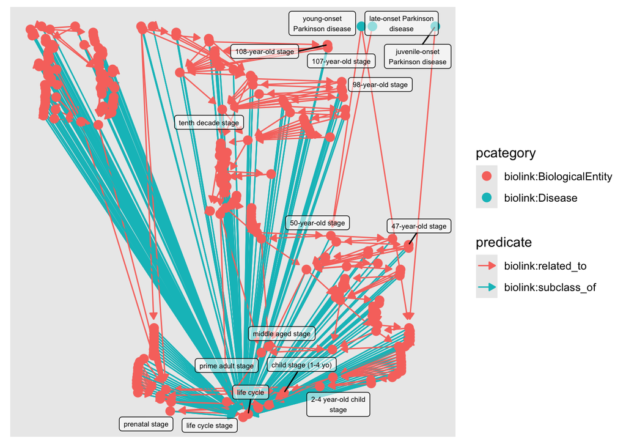

```r
quickplot(stages_expanded)
```

Ok, `biolink:related_to` seems to be of interest, connecting many of the life stages. Altogether these are related-to just three diseases (juvenile, young, and late-onset Parkinsons). Let’s look at just the hierarchy within this graph, dropping the sublass info cluttering the graph.

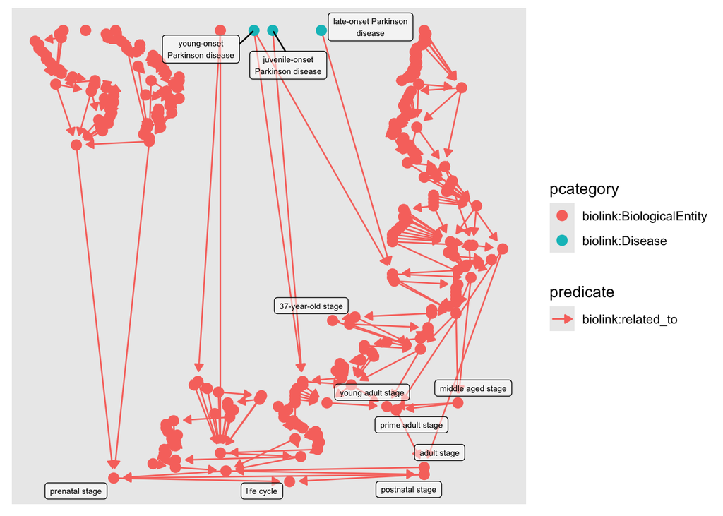

```r
stages_expanded |>
    activate(edges) |>
    filter(predicate == "biolink:related_to") |>
    quickplot()
```

Ok… that’s a bit better; there are a bunch of stages still cluttering this up, of the form “X year-old stage”, “X month-old stage”, and “Carnegie stage X”. Let’s drop those too.

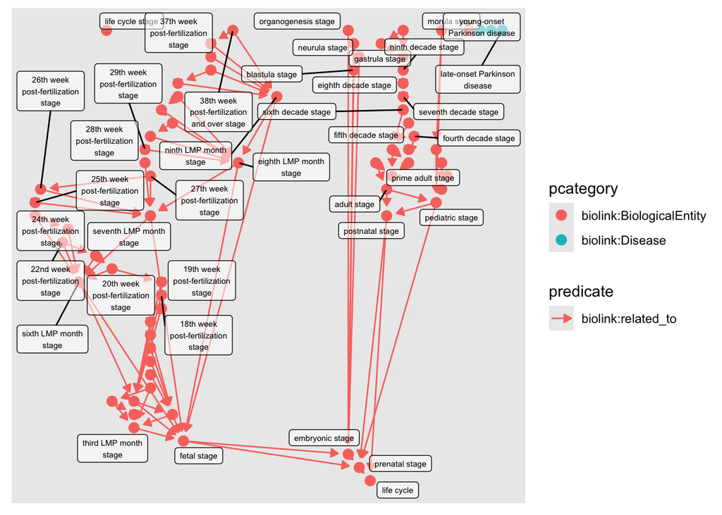

```r
stages_expanded |>
    activate(edges) |>
    filter(predicate == "biolink:related_to") |>
    activate(nodes) |>
    filter(!str_detect(name, "Carnegie") & !str_detect(name, "year-old") & !str_detect(name, "month-old")) |>
    quickplot()
```

Welp, on zooming in, while there are stages such as adult and pediatric, those are connected via a “related to”, so this is not a clean transitive organization like we would expect with subclass-of, and as discovered above there’s not much structured provded by subclass-of, nor are these connected much else in the graph (except for Parkinsons).

Perhaps there are other life-stage-like entities in the KG to look for?